```python
import os
print("Notebook directory:", os.getcwd())
print("\n")
print("Full path:", os.path.abspath("01_data_extraction.ipynb"))

# ==========================================================
# SUPPRESS NON-FATAL FUTUREWARNING FROM PANDAS_DATAREADER I/O
# ==========================================================
import warnings

# ==========================================================
# FILTER FUTUREWARNING CATEGORY FOR CLEANER NOTEBOOK OUTPUT
# ==========================================================
warnings.filterwarnings("ignore", category=FutureWarning)
```

```
Notebook directory: C:\Users\steve\Documents\01_ACADEMIA\WQU\MScFE_692_Capstone_Project\riskml-capstone\notebooks


Full path: C:\Users\steve\Documents\01_ACADEMIA\WQU\MScFE_692_Capstone_Project\riskml-capstone\notebooks\01_data_extraction.ipynb
```

# Notebook 01:

# Data Extraction — Daily Panel (2015 → Present)

**📘 PURPOSE:** A reproducible data-ingestion and validation notebook that constructs the full daily panel required for downstream feature engineering, risk forecasting baselines, manual-DAG constrained modeling, and portfolio analytics.

## CAPSTONE CONTEXT

**Title:**  
**Causal-Aware, Machine-Learning-Driven Factor-Informed Risk Forecasting:** A Python–Azure Pipeline Integrating NLP, Directed Factor Constraints, and Portfolio Analytics

**Thesis:**  
A small, manually specified **Directed Acyclic Graph (DAG)** encoding economically motivated directional constraints (directional constraints, not identified causal effects) over factor exposures, sentiment signals, and risk estimates can measurably improve out-of-sample risk forecast accuracy, portfolio-level risk control, and factor-exposure interpretability relative to an unconstrained machine-learning baseline, within a reproducible pipeline validated by ablation and regime-aware evaluation.

**Research Question:**  
How does imposing **manual causal constraints** on an ML-driven risk forecasting pipeline affect forecast accuracy, portfolio performance, and interpretability compared to unconstrained baseline models?

## MANUAL DAG (Conceptual Constraint Layer)

**🔗 DAG STRUCTURE:**

```
Sentiment  →  Momentum  →  Returns
```

Path 1: Sentiment **AMPLIFIES** Momentum; Momentum **FORECASTS** Returns

```
Value (HML)            →  Returns
```

Path 2: Value (HML) **EXPLAINS** Returns

```
Volatility →  Risk     →  Allocation
```

Path 3: Volatility **ESTIMATES** Risk; Risk **CONSTRAINS** Allocation

**Interpretation:** The DAG encodes economically defensible directional constraints. Sentiment amplifies momentum through herding and feedback loops. Momentum forecasts near-term returns. Value exposure (HML factor) explains cross-sectional return variation. Volatility estimates risk, which constrains allocation decisions through optimization bounds.

## DATASETS AND ROLES (ETL MANIFEST)

| Dataset | Series | Primary Role | Source | Storage |
| --- | --- | --- | --- | --- |
| ETF Adjusted Prices | SPY, QQQ, IWM, EFA, EEM, XLK, XLF, XLE, XLV, TLT, LQD, HYG, GLD, DBC | Returns + Volatility + Portfolio Backtests | Yahoo Finance (`yfinance`) | `data/raw/etf_prices.parquet` |
| ETF Log Returns | Same 14 ETFs | Canonical trading-day calendar | Derived from prices | `data/processed/etf_returns.parquet` |
| Fama–French 3-Factor Model | Mkt-RF, SMB, HML, RF | Value proxy (HML) + market/size risk decomposition | Fama–French Data Library | `data/raw/ff_factors.parquet` |
| FRED Macro Series | DTB3, VIXCLS, T10Y2Y | Regime + risk-free + macro risk | Federal Reserve (FRED) | `data/raw/macro_fred.parquet` |
| News/RSS Headlines (Raw) | Market_Headlines, Sector_Headlines_Tech, Sector_Headlines_Financials, Sector_Headlines_Energy, Sector_Headlines_Healthcare (sector tags aligned to XLK/XLF/XLE/XLV via GICS-style mapping) | Upstream source for Sentiment node; NLP pipeline input; schema: `timestamp_utc`, `source`, `headline`, `url`, `tag`, `headline_id` | RSS feeds + parsing | `data/raw/rss_headlines.parquet` |
| Sentiment (Processed) | Sentiment_Market | Derived sentiment scores for DAG Sentiment node | Derived from News/RSS Headlines | `data/processed/sentiment_daily.parquet` |
| Master Panel | Returns + factors + macro + sentiment | Single canonical panel | Merged | `data/processed/master_panel.parquet` |

## DATA DICTIONARY (CORE COLUMNS)

**📋 MASTER PANEL INDEX:** `Date` (trading-day calendar derived from ETF returns; timezone-naive; no weekends or holidays)

### FILES (HIGH-LEVEL)

| File | Granularity | Primary Key / Index | Description |
| --- | --- | --- | --- |
| `data/raw/etf_prices.parquet` | Daily | `Date` index | Adjusted close prices for 14 ETFs |
| `data/processed/etf_returns.parquet` | Daily | `Date` index | Daily log returns for 14 ETFs |
| `data/raw/ff_factors.parquet` | Daily | `Date` index | Fama–French daily factors (decimal units) |
| `data/raw/macro_fred.parquet` | Daily (as available) | `Date` index | FRED macro series; aligned to trading calendar via forward-fill |
| `data/raw/rss_headlines.parquet` | Event-level | `headline_id` | Raw headlines with timestamp, source, tags |
| `data/processed/sentiment_daily.parquet` | Daily | `Date` index | Aggregated daily sentiment score(s) derived from RSS headlines |
| `data/processed/master_panel.parquet` | Daily | `Date` index | Returns + factors + macro + sentiment merged into one panel |

### ETF FILES

| File | Columns | Values | Units |
| --- | --- | --- | --- |
| `etf_prices.parquet` | 14 ETF tickers | Adjusted close price | USD |
| `etf_returns.parquet` | 14 ETF tickers | Daily log return | Unitless (decimal) |

### FAMA–FRENCH 3-FACTOR MODEL (converted from percent to decimal)

| Column | Description | Units |
| --- | --- | --- |
| `Mkt-RF` | Market excess return (market return minus risk-free rate) | Decimal, daily |
| `SMB` | Size factor (Small Minus Big) | Decimal, daily |
| `HML` | Value factor (High Minus Low) | Decimal, daily |
| `RF` | Risk-free rate (for computing portfolio excess returns) | Decimal, daily |

### FRED MACRO SERIES (stored as returned by FRED)

| Column | FRED Code | Description | Units / Notes |
| --- | --- | --- | --- |
| `DTB3` | DTB3 | 3-month Treasury bill rate | Percent level (convert to decimal later if needed) |
| `VIXCLS` | VIXCLS | VIX index closing level | Index level (unitless) |
| `T10Y2Y` | T10Y2Y | 10-year minus 2-year yield spread | Percent spread level |

### NEWS/RSS HEADLINES (RAW)

| Column | Description | Week 2 Value | Week 3–4 Value |
| --- | --- | --- | --- |
| `timestamp_utc` | Publication timestamp (UTC) | Schema defined; file empty | Populated from RSS feeds |
| `source` | RSS feed source identifier | Schema defined; file empty | e.g., "Reuters", "MarketWatch" |
| `headline` | Raw headline text | Schema defined; file empty | Headline string |
| `url` | Article URL | Schema defined; file empty | Full URL |
| `tag` | Sector tag (Market, Tech, Financials, Energy, Healthcare); mapping aligned to XLK/XLF/XLE/XLV | Schema defined; file empty | Assigned by tagging logic |
| `headline_id` | Stable hash ID for deduplication (SHA-256 over headline + timestamp) | Schema defined; file empty | Computed hash ID |

### SENTIMENT (PROCESSED)

| Column | Description | Week 2 Value | Week 3–4 Replacement |
| --- | --- | --- | --- |
| `Sentiment_Market` | Aggregated daily market sentiment score | `NaN` placeholder (pipeline continuity) | Computed from RSS headlines via NLP model |

## LOG RETURNS TRANSFORMATION EQUATION

**📐 DEFINITION — Daily Log Returns:**

$$ r_t = \ln(P_t) - \ln(P_{t-1}) = \ln\left(\frac{P_t}{P_{t-1}}\right) $$

**Where:**

- $r_t$ = daily log return on trading day $t$
- $P_t$ = adjusted close price on trading day $t$
- $P_{t-1}$ = adjusted close price on the previous trading day
- $\ln$ = natural logarithm

**Why log returns?** Log returns are time-additive (multi-period returns sum), approximately normally distributed for small values, and symmetric around zero. These properties support stable statistical modeling and portfolio analytics.

## OUTPUTS

**📁 FILES CREATED BY THIS NOTEBOOK:**

**Processed Data (`data/processed/`):**

- `etf_returns.parquet` — Daily log returns for 14 ETFs
- `master_panel.parquet` — Merged panel (returns + factors + macro + sentiment)
- `data_freeze_v1.txt` — Metadata tag for reproducibility tracking

## REPRODUCIBILITY

**✅ REPRODUCIBILITY GUARANTEES:**

| Dimension | Policy |
| --- | --- |
| **Random Seed** | 692 (set in setup cell) |
| **Time Ordering** | Preserved (no shuffling) |
| **Look-Ahead Leakage** | None (download + transformation only) |
| **Data Freeze** | Metadata tag created at notebook end |
| **Index Alignment** | Trading-day calendar from ETF returns |
| **Timezone Handling** | Timezone-naive datetime index |

**🚨 LEAKAGE WARNING:** This notebook performs *data download and transformation only*. No model training, no validation splits, no feature engineering beyond log returns. Any code that "peeks" at future data violates the reproducibility contract.

## NOTEBOOK STRUCTURE OVERVIEW

| Cell Block | Purpose | Key Actions |
| --- | --- | --- |
| **SETUP** | Environment initialization | Imports, paths, seed, display options |
| **CONFIG** | Parameter definitions | Tickers, dates, FRED codes, paths |
| **ETF DOWNLOAD** | Price ingestion | yfinance download with fallback |
| **FRED DOWNLOAD** | Macro ingestion | FRED API with forward-fill |
| **FF DOWNLOAD** | Factor ingestion | pandas-datareader with unit conversion |
| **RETURNS** | Log return computation | Price → return transformation |
| **MERGE** | Panel construction | Left-join onto trading-day calendar |
| **VALIDATION** | Sanity checks | Missingness, duplicates, outliers |
| **FREEZE** | Data freeze tag | Metadata export |

*Notebook 01 of 7 | MScFE 692 Capstone | Steven Archuleta | WorldQuant University* *C:\Users\steve\Documents\01_ACADEMIA\WQU\MScFE_692_Capstone_Project\06_NB_MARKDOWN_CELLS\01_data_extraction_NB_MD\NB_MD_01_Introductory_Cell_v3.md*

```python
# ============
# CODE_BLOCK_A
# ============
# ================================================
# NOTEBOOK SETUP: IMPORTS, PATHS, DISPLAY DEFAULTS
# ================================================

# ============================================================================
# IMPORT OPERATING SYSTEM MODULE FOR ENVIRONMENT VARIABLES AND FILE OPERATIONS
# ============================================================================
import os

# ===============================================
# IMPORT SYSTEM MODULE FOR PYTHON PATH MANAGEMENT
# ===============================================
import sys

# ===================================================
# IMPORT TIME MODULE FOR THROTTLING DOWNLOAD REQUESTS
# ===================================================
import time

# ==================================================
# IMPORT HASHLIB MODULE FOR DATA FREEZE FILE HASHING
# ==================================================
import hashlib

# ======================================================
# IMPORT PATH CLASS FOR CROSS-PLATFORM PATH CONSTRUCTION
# ======================================================
from pathlib import Path

# ========================================
# IMPORT DATETIME CLASS FOR RUN TIMESTAMPS
# ========================================
from datetime import datetime

# =====================================
# IMPORT NUMPY FOR NUMERICAL OPERATIONS
# =====================================
import numpy as np

# ======================================
# IMPORT PANDAS FOR DATAFRAME OPERATIONS
# ======================================
import pandas as pd

# ==============================
# IMPORT MATPLOTLIB FOR PLOTTING
# ==============================
import matplotlib.pyplot as plt

# ===============================================
# IMPORT YFINANCE FOR YAHOO FINANCE DATA DOWNLOAD
# ===============================================
import yfinance as yf

# ===========================================================
# IMPORT PANDAS_DATAREADER FOR FAMA-FRENCH AND STOOQ FALLBACK
# ===========================================================
import pandas_datareader.data as web

# ================================================================
# IMPORT DOTENV LOADER FOR LOCAL .ENV FILE SUPPORT (IF INSTALLED)
# ================================================================
try:
    from dotenv import load_dotenv
except ImportError as exc:
    print(f"WARNING: python-dotenv not available. Exception: {repr(exc)}")
    load_dotenv = None

# =============================================================
# IMPORT FRED CLIENT FOR FRED MACRO SERIES DOWNLOAD (IF INSTALLED)
# =============================================================
try:
    from fredapi import Fred
except ImportError as exc:
    print(f"WARNING: fredapi not available. Exception: {repr(exc)}")
    Fred = None

# ==========================================================
# LOAD ENVIRONMENT VARIABLES FROM LOCAL .ENV FILE IF PRESENT
# ==========================================================
if load_dotenv is not None:
    load_dotenv()

# ====================================
# DEFINE REPRODUCIBILITY SEED CONSTANT
# ====================================
RANDOM_SEED = 692

# ==========================================================
# APPLY NUMPY RANDOM SEED FOR REPRODUCIBLE RANDOM OPERATIONS
# ==========================================================
np.random.seed(RANDOM_SEED)

# ======================================
# CAPTURE CURRENT WORKING DIRECTORY PATH
# ======================================
CURRENT_PATH = Path.cwd()

# ======================================================
# SET PROJECT ROOT PATH USING NOTEBOOKS FOLDER HEURISTIC
# ======================================================
PROJECT_ROOT = CURRENT_PATH.parent if CURRENT_PATH.name == "notebooks" else CURRENT_PATH

# ==============================
# DEFINE RAW DATA DIRECTORY PATH
# ==============================
DATA_RAW = PROJECT_ROOT / "data" / "raw"

# ====================================
# DEFINE PROCESSED DATA DIRECTORY PATH
# ====================================
DATA_PROCESSED = PROJECT_ROOT / "data" / "processed"

# ====================================
# DEFINE REPORT FIGURES DIRECTORY PATH
# ====================================
REPORTS_FIGURES = PROJECT_ROOT / "reports" / "figures"

# =========================
# CREATE RAW DATA DIRECTORY
# =========================
DATA_RAW.mkdir(parents=True, exist_ok=True)

# ===============================
# CREATE PROCESSED DATA DIRECTORY
# ===============================
DATA_PROCESSED.mkdir(parents=True, exist_ok=True)

# ===============================
# CREATE REPORT FIGURES DIRECTORY
# ===============================
REPORTS_FIGURES.mkdir(parents=True, exist_ok=True)

# ==================================================
# INSERT PROJECT ROOT INTO PYTHON MODULE SEARCH PATH
# ==================================================
sys.path.insert(0, str(PROJECT_ROOT))

# =============================================
# SET PANDAS DISPLAY OPTION FOR MAXIMUM COLUMNS
# =============================================
pd.set_option("display.max_columns", 60)

# ===========================================
# SET PANDAS DISPLAY OPTION FOR DISPLAY WIDTH
# ===========================================
pd.set_option("display.width", 180)

# ==========================================
# SET PANDAS DISPLAY OPTION FOR FLOAT FORMAT
# ==========================================
pd.set_option("display.float_format", lambda value: f"{value:,.6f}")

# ==================================
# SET MATPLOTLIB FIGURE SIZE DEFAULT
# ==================================
plt.rcParams["figure.figsize"] = (12, 6)

# ==============================
# ENABLE MATPLOTLIB GRID DEFAULT
# ==============================
plt.rcParams["axes.grid"] = True

# ================================
# SET MATPLOTLIB FONT SIZE DEFAULT
# ================================
plt.rcParams["font.size"] = 11

# ========================================
# PRINT PROJECT ROOT PATH FOR VERIFICATION
# ========================================
print(f"PROJECT_ROOT: {PROJECT_ROOT}")
print("\n")
# ====================================
# PRINT RAW DATA PATH FOR VERIFICATION
# ====================================
print(f"DATA_RAW: {DATA_RAW}")
print("\n")
# ==========================================
# PRINT PROCESSED DATA PATH FOR VERIFICATION
# ==========================================
print(f"DATA_PROCESSED: {DATA_PROCESSED}")
print("\n")
# ===================================
# PRINT FIGURES PATH FOR VERIFICATION
# ===================================
print(f"REPORTS_FIGURES: {REPORTS_FIGURES}")
print("\n")
# ===============================
# PRINT TIMESTAMP FOR RUN LOGGING
# ===============================
print(f"RUN_TIMESTAMP: {datetime.now().strftime('%Y-%m-%d %H:%M:%S')}")
```

```
PROJECT_ROOT: C:\Users\steve\Documents\01_ACADEMIA\WQU\MScFE_692_Capstone_Project\riskml-capstone


DATA_RAW: C:\Users\steve\Documents\01_ACADEMIA\WQU\MScFE_692_Capstone_Project\riskml-capstone\data\raw


DATA_PROCESSED: C:\Users\steve\Documents\01_ACADEMIA\WQU\MScFE_692_Capstone_Project\riskml-capstone\data\processed


REPORTS_FIGURES: C:\Users\steve\Documents\01_ACADEMIA\WQU\MScFE_692_Capstone_Project\riskml-capstone\reports\figures


RUN_TIMESTAMP: 2026-02-19 09:39:10
```

### 📌 Observations and Insights for CODE_BLOCK_A

**✅ VALIDATION STATUS:** PASSED

**⚙️ WHAT THE CODE ACCOMPLISHED:**

- Imported all required libraries for ETL pipeline (os, sys, time, hashlib, pathlib, datetime, numpy, pandas, matplotlib, yfinance, pandas_datareader, dotenv, fredapi)
- Loaded environment variables from `.env` file (FRED API key now available)
- Set reproducibility seed constant (RANDOM_SEED = 692) and applied to NumPy random generator
- Detected notebook location and computed PROJECT_ROOT using the notebooks folder heuristic
- Defined canonical data directory paths (DATA_RAW, DATA_PROCESSED, REPORTS_FIGURES)
- Created data directories if not already present (mkdir with parents=True, exist_ok=True)
- Inserted PROJECT_ROOT into Python module search path for future `riskml` package imports
- Configured pandas display options (max_columns=60, width=180, float_format with 6 decimals)
- Configured matplotlib defaults (figure size 12×6, grid enabled, font size 11)

**📤 KEY OUTPUTS:**

- `PROJECT_ROOT`: `C:\Users\steve\Documents\01_ACADEMIA\WQU\MScFE_692_Capstone_Project\riskml-capstone`
- `DATA_RAW`: `...\riskml-capstone\data\raw`
- `DATA_PROCESSED`: `...\riskml-capstone\data\processed`
- `REPORTS_FIGURES`: `...\riskml-capstone\reports\figures`
- `RUN_TIMESTAMP`: `2026-02-19 09:39:10`

**🔍 OBSERVATIONS:**

- **✓** PROJECT_ROOT correctly resolved to `riskml-capstone` repository root (notebook is running from `notebooks/` subfolder)
- **✓** No import warnings printed — `python-dotenv` and `fredapi` packages are installed and available
- **✓** Data directories exist and are ready for downstream parquet writes
- **✓** Timestamp confirms notebook execution date for reproducibility tracking

```python
# ============
# CODE_BLOCK_B
# ============
# ===============================================
# CONFIGURATION: UNIVERSE, DATES, PATHS, POLICIES
# ===============================================

# ==========================================
# DEFINE ETF TICKER UNIVERSE FOR DAILY PANEL
# ==========================================
TICKERS = [
    "SPY", "QQQ", "IWM", "EFA", "EEM",
    "XLK", "XLF", "XLE", "XLV",
    "TLT", "LQD", "HYG",
    "GLD", "DBC"
]

# ==========================================
# DEFINE START DATE STRING FOR ALL DOWNLOADS
# ==========================================
START_DATE = "2015-01-01"

# =================================================
# DEFINE END DATE PLACEHOLDER FOR LATEST AVAILABLE
# =================================================
END_DATE = None

# ========================================
# DEFINE FRED SERIES CODES FOR MACRO PANEL
# ========================================
FRED_SERIES = ["DTB3", "VIXCLS", "T10Y2Y"]

# =================================================
# DEFINE FAMA-FRENCH DATASET NAME FOR DAILY FACTORS
# =================================================
FF_DATASET = "F-F_Research_Data_Factors_daily"

# ==========================
# DEFINE PARQUET ENGINE NAME
# ==========================
PARQUET_ENGINE = "pyarrow"

# ===============================
# DEFINE PARQUET COMPRESSION NAME
# ===============================
PARQUET_COMPRESSION = "snappy"

# ===========================================================
# DEFINE CACHE POLICY FLAG FOR REUSING EXISTING PARQUET FILES
# ===========================================================
USE_CACHE = True

# ==================================================
# DEFINE YFINANCE RETRY COUNT FOR NETWORK RESILIENCE
# ==================================================
YFINANCE_MAX_RETRIES = 3

# ============================================================
# DEFINE YFINANCE SLEEP SECONDS BETWEEN RETRIES FOR THROTTLING
# ============================================================
YFINANCE_SLEEP_SECONDS = 2.0

# =================================================================
# DEFINE STOOQ FALLBACK ENABLE FLAG FOR ETF PRICE DOWNLOAD FAILURES
# =================================================================
ENABLE_STOOQ_FALLBACK = True

# ====================================================
# DEFINE OUTPUT PATH FOR RAW ETF PRICES ADJUSTED CLOSE
# ====================================================
PATH_ETF_PRICES = DATA_RAW / "etf_prices.parquet"

# ===================================================
# DEFINE OUTPUT PATH FOR RAW FAMA-FRENCH DAILY FACTORS
# ===================================================
PATH_FF_FACTORS = DATA_RAW / "ff_factors.parquet"

# ============================================
# DEFINE OUTPUT PATH FOR RAW FRED MACRO SERIES
# ============================================
PATH_MACRO_FRED = DATA_RAW / "macro_fred.parquet"

# ====================================================
# DEFINE OUTPUT PATH FOR RAW RSS HEADLINES EVENT LEVEL
# ====================================================
PATH_RSS_HEADLINES = DATA_RAW / "rss_headlines.parquet"

# ================================================
# DEFINE OUTPUT PATH FOR PROCESSED ETF LOG RETURNS
# ================================================
PATH_ETF_RETURNS = DATA_PROCESSED / "etf_returns.parquet"

# ===========================================================
# DEFINE OUTPUT PATH FOR PROCESSED SENTIMENT DAILY AGGREGATION
# ===========================================================
PATH_SENTIMENT = DATA_PROCESSED / "sentiment_daily.parquet"

# ==============================================
# DEFINE OUTPUT PATH FOR PROCESSED MASTER PANEL
# ==============================================
PATH_MASTER_PANEL = DATA_PROCESSED / "master_panel.parquet"

# ==============================================
# DEFINE OUTPUT PATH FOR DATA FREEZE METADATA TAG
# ==============================================
PATH_DATA_FREEZE = DATA_PROCESSED / "data_freeze_v1.txt"

# ============================================
# PRINT CONFIGURATION SUMMARY FOR VERIFICATION
# ============================================
print("CONFIGURATION SUMMARY")
print(f"  TICKER_COUNT: {len(TICKERS)}")
print(f"  TICKERS: {TICKERS}")
print(f"  START_DATE: {START_DATE}")
print(f"  END_DATE: {END_DATE}")
print(f"  FRED_SERIES: {FRED_SERIES}")
print(f"  FF_DATASET: {FF_DATASET}")
print(f"  PARQUET_ENGINE: {PARQUET_ENGINE}")
print(f"  PARQUET_COMPRESSION: {PARQUET_COMPRESSION}")
print(f"  USE_CACHE: {USE_CACHE}")
print(f"  YFINANCE_MAX_RETRIES: {YFINANCE_MAX_RETRIES}")
print(f"  YFINANCE_SLEEP_SECONDS: {YFINANCE_SLEEP_SECONDS}")
print(f"  ENABLE_STOOQ_FALLBACK: {ENABLE_STOOQ_FALLBACK}")
print("\n")
print("OUTPUT PATHS (RAW):")
print(f"  PATH_ETF_PRICES: {PATH_ETF_PRICES}")
print(f"  PATH_FF_FACTORS: {PATH_FF_FACTORS}")
print(f"  PATH_MACRO_FRED: {PATH_MACRO_FRED}")
print(f"  PATH_RSS_HEADLINES: {PATH_RSS_HEADLINES}")
print("\n")
print("OUTPUT PATHS (PROCESSED):")
print(f"  PATH_ETF_RETURNS: {PATH_ETF_RETURNS}")
print(f"  PATH_SENTIMENT: {PATH_SENTIMENT}")
print(f"  PATH_MASTER_PANEL: {PATH_MASTER_PANEL}")
print(f"  PATH_DATA_FREEZE: {PATH_DATA_FREEZE}")
```

```
CONFIGURATION SUMMARY
  TICKER_COUNT: 14
  TICKERS: ['SPY', 'QQQ', 'IWM', 'EFA', 'EEM', 'XLK', 'XLF', 'XLE', 'XLV', 'TLT', 'LQD', 'HYG', 'GLD', 'DBC']
  START_DATE: 2015-01-01
  END_DATE: None
  FRED_SERIES: ['DTB3', 'VIXCLS', 'T10Y2Y']
  FF_DATASET: F-F_Research_Data_Factors_daily
  PARQUET_ENGINE: pyarrow
  PARQUET_COMPRESSION: snappy
  USE_CACHE: True
  YFINANCE_MAX_RETRIES: 3
  YFINANCE_SLEEP_SECONDS: 2.0
  ENABLE_STOOQ_FALLBACK: True


OUTPUT PATHS (RAW):
  PATH_ETF_PRICES: C:\Users\steve\Documents\01_ACADEMIA\WQU\MScFE_692_Capstone_Project\riskml-capstone\data\raw\etf_prices.parquet
  PATH_FF_FACTORS: C:\Users\steve\Documents\01_ACADEMIA\WQU\MScFE_692_Capstone_Project\riskml-capstone\data\raw\ff_factors.parquet
  PATH_MACRO_FRED: C:\Users\steve\Documents\01_ACADEMIA\WQU\MScFE_692_Capstone_Project\riskml-capstone\data\raw\macro_fred.parquet
  PATH_RSS_HEADLINES: C:\Users\steve\Documents\01_ACADEMIA\WQU\MScFE_692_Capstone_Project\riskml-capstone\data\raw\rss_headlines.parquet


OUTPUT PATHS (PROCESSED):
  PATH_ETF_RETURNS: C:\Users\steve\Documents\01_ACADEMIA\WQU\MScFE_692_Capstone_Project\riskml-capstone\data\processed\etf_returns.parquet
  PATH_SENTIMENT: C:\Users\steve\Documents\01_ACADEMIA\WQU\MScFE_692_Capstone_Project\riskml-capstone\data\processed\sentiment_daily.parquet
  PATH_MASTER_PANEL: C:\Users\steve\Documents\01_ACADEMIA\WQU\MScFE_692_Capstone_Project\riskml-capstone\data\processed\master_panel.parquet
  PATH_DATA_FREEZE: C:\Users\steve\Documents\01_ACADEMIA\WQU\MScFE_692_Capstone_Project\riskml-capstone\data\processed\data_freeze_v1.txt
```

### 📌 Observations and Insights for CODE_BLOCK_B

**✅ VALIDATION STATUS:** PASSED

**⚙️ WHAT THE CODE ACCOMPLISHED:**

- Defined ETF ticker universe (14 ETFs spanning US equity, international, sector, fixed income, and commodities)
- Set data extraction date range (2015-01-01 to present via END_DATE = None)
- Specified FRED macro series codes (DTB3, VIXCLS, T10Y2Y) for regime and risk features
- Specified Fama-French dataset name for daily 3-factor download
- Configured parquet storage settings (pyarrow engine, snappy compression)
- Set caching policy (USE_CACHE = True) for skipping redundant downloads
- Configured network resilience parameters (3 retries, 2.0 second sleep between retries)
- Enabled Stooq fallback for ETF price download failures
- Defined all raw output paths (etf_prices, ff_factors, macro_fred, rss_headlines)
- Defined all processed output paths (etf_returns, sentiment_daily, master_panel, data_freeze_v1)

**📤 KEY OUTPUTS:**

- `TICKER_COUNT`: 14 (matches ETL manifest: SPY, QQQ, IWM, EFA, EEM, XLK, XLF, XLE, XLV, TLT, LQD, HYG, GLD, DBC)
- `START_DATE`: 2015-01-01 (provides ~10 years of daily data including multiple regime periods)
- `END_DATE`: None (downloads through latest available trading day)
- `FRED_SERIES`: ['DTB3', 'VIXCLS', 'T10Y2Y'] (risk-free rate, volatility regime, yield curve slope)
- `FF_DATASET`: F-F_Research_Data_Factors_daily (Mkt-RF, SMB, HML, RF)
- All 8 output paths correctly resolve to `riskml-capstone/data/raw/` and `riskml-capstone/data/processed/`

**🔍 OBSERVATIONS:**

- **✓** Ticker count (14) matches the ETL manifest and capstone outline exactly
- **✓** Raw paths write to `data/raw/` and processed paths write to `data/processed/` (governance separation confirmed)
- **✓** RSS headlines path included for Week 3–4 NLP pipeline (schema-only file in Week 2)
- **✓** Sentiment path correctly points to `data/processed/` (derived data, not raw)
- **⚠** USE_CACHE = True means that the existing parquet files will be reused; set USE_CACHE to False in order to force re-download

```python
# ============
# CODE_BLOCK_C
# ============
# ==========================================================
# UTILITIES: IO, INDEX HYGIENE, MISSINGNESS SUMMARY, HASHING
# ==========================================================

# ========================================================
# DEFINE FUNCTION FOR PARQUET SAVE WITH CONSISTENT OPTIONS
# ========================================================
def save_parquet(df: pd.DataFrame, path: Path) -> None:
    # =======================================
    # CREATE PARENT DIRECTORY PATH FOR SAFETY
    # =======================================
    path.parent.mkdir(parents=True, exist_ok=True)
    # =========================================================
    # ENSURE INDEX NAME EXISTS FOR TRACEABILITY IN STORED FILES
    # =========================================================
    if df.index.name is None:
        # ===================================
        # SET DEFAULT INDEX NAME WHEN MISSING
        # ===================================
        df.index.name = "Date"
    # ======================================================
    # WRITE DATAFRAME TO PARQUET WITH ENGINE AND COMPRESSION
    # ======================================================
    df.to_parquet(
        path,
        engine=PARQUET_ENGINE,
        compression=PARQUET_COMPRESSION,
        index=True
    )
    # =================================================
    # PRINT SAVE CONFIRMATION FOR NOTEBOOK TRACEABILITY
    # =================================================
    print(f"SAVED_PARQUET: {path} | SHAPE: {df.shape}")

# ========================================================
# DEFINE FUNCTION FOR PARQUET LOAD WITH BASIC TRACE OUTPUT
# ========================================================
def load_parquet(path: Path) -> pd.DataFrame:
    # =============================================
    # FAIL FAST WHEN REQUESTED FILE DOES NOT EXIST
    # =============================================
    if not path.exists():
        # ==========================================
        # RAISE FILE NOT FOUND ERROR WITH FULL PATH
        # ==========================================
        raise FileNotFoundError(f"PARQUET_FILE_NOT_FOUND: {path}")
    # ================================
    # READ PARQUET FILE INTO DATAFRAME
    # ================================
    df = pd.read_parquet(path, engine=PARQUET_ENGINE)
    # =================================================
    # PRINT LOAD CONFIRMATION FOR NOTEBOOK TRACEABILITY
    # =================================================
    print(f"LOADED_PARQUET: {path} | SHAPE: {df.shape}")
    # =======================
    # RETURN DATAFRAME OBJECT
    # =======================
    return df

# ==================================================================
# DEFINE FUNCTION FOR DATETIMEINDEX ENFORCEMENT, SORT, AND DEDUP CHECK
# ==================================================================
def enforce_datetime_index(df: pd.DataFrame, df_name: str) -> pd.DataFrame:
    # ==================================================
    # CONVERT INDEX TO DATETIMEINDEX USING PANDAS PARSER
    # ==================================================
    df.index = pd.to_datetime(df.index)
    # ====================================================
    # REMOVE TIMEZONE INFORMATION FOR CONSISTENT JOIN KEYS
    # ====================================================
    if getattr(df.index, "tz", None) is not None:
        # ====================================================
        # CONVERT TIMEZONE-AWARE INDEX TO TIMEZONE-NAIVE INDEX
        # ====================================================
        df.index = df.index.tz_convert(None)
    # ====================================================
    # SORT INDEX IN ASCENDING ORDER FOR TIME-SERIES SAFETY
    # ====================================================
    df = df.sort_index()
    # ==========================================
    # CHECK DUPLICATE INDEX VALUES AND FAIL FAST
    # ==========================================
    if df.index.duplicated().any():
        # ===============================================
        # RAISE EXCEPTION FOR DATA GOVERNANCE ENFORCEMENT
        # ===============================================
        raise ValueError(f"DUPLICATE_DATES_DETECTED: {df_name}")
    # =====================================================
    # PRINT INDEX RANGE FOR QUICK VALIDATION WHEN NON-EMPTY
    # =====================================================
    if df.shape[0] > 0:
        # ==================================================
        # PRINT MIN DATE, MAX DATE, AND ROW COUNT FOR REVIEW
        # ==================================================
        print(f"{df_name}_DATE_RANGE: {df.index.min().date()} → {df.index.max().date()} | ROWS: {df.shape[0]}")
    else:
        # ============================================
        # PRINT EMPTY DATAFRAME MESSAGE FOR DIAGNOSTIC
        # ============================================
        print(f"{df_name}_DATE_RANGE: EMPTY_DATAFRAME | ROWS: 0")
    # ========================
    # RETURN CLEANED DATAFRAME
    # ========================
    return df

# =============================================
# DEFINE FUNCTION FOR MISSINGNESS SUMMARY TABLE
# =============================================
def missingness_table(df: pd.DataFrame, df_name: str) -> pd.DataFrame:
    # ======================================
    # COMPUTE MISSING VALUE COUNTS BY COLUMN
    # ======================================
    missing_count = df.isna().sum()
    # ====================================================
    # COMPUTE MISSING VALUE FRACTION WITH EMPTY-FRAME GUARD
    # ====================================================
    if df.shape[0] == 0:
        # ========================================
        # DEFINE ZERO FRACTIONS WHEN NO ROWS EXIST
        # ========================================
        missing_frac = missing_count * 0.0
    else:
        # ============================================
        # COMPUTE FRACTION USING ROW COUNT DENOMINATOR
        # ============================================
        missing_frac = missing_count / float(df.shape[0])
    # ============================================
    # BUILD SUMMARY DATAFRAME FOR NOTEBOOK DISPLAY
    # ============================================
    summary_df = pd.DataFrame({
        "missing_count": missing_count,
        "missing_frac": missing_frac
    }).sort_values("missing_count", ascending=False)
    # ===================================
    # PRINT TOP ROWS FOR QUICK INSPECTION
    # ===================================
    print(f"MISSINGNESS_SUMMARY: {df_name}")
    print(summary_df.head(15))
    # ========================
    # RETURN SUMMARY DATAFRAME
    # ========================
    return summary_df

# ==============================================
# DEFINE FUNCTION FOR SHA256 HASH OF A FILE PATH
# ==============================================
def sha256_file(path: Path) -> str:
    # =============================
    # INITIALIZE SHA256 HASH OBJECT
    # =============================
    h = hashlib.sha256()
    # ===============================================
    # OPEN FILE IN BINARY MODE FOR BYTE-LEVEL HASHING
    # ===============================================
    with open(path, "rb") as f:
        # =======================================
        # STREAM FILE BY CHUNKS FOR MEMORY SAFETY
        # =======================================
        for chunk in iter(lambda: f.read(1024 * 1024), b""):
            # ==========================================
            # UPDATE HASH STATE WITH CURRENT CHUNK BYTES
            # ==========================================
            h.update(chunk)
    # =============================================
    # RETURN HEX DIGEST STRING FOR METADATA LOGGING
    # =============================================
    return h.hexdigest()

# ===============================
# PRINT UTILITY LOAD CONFIRMATION
# ===============================
print("\n")
print("UTILITY FUNCTIONS READY: save_parquet, load_parquet, enforce_datetime_index, missingness_table, sha256_file")
```

```
UTILITY FUNCTIONS READY: save_parquet, load_parquet, enforce_datetime_index, missingness_table, sha256_file
```

### 📌 Observations and Insights for CODE_BLOCK_C

**✅ VALIDATION STATUS:** PASSED

**⚙️ WHAT THE CODE ACCOMPLISHED:**

- Defined 5 utility functions for use throughout the ETL pipeline
- Functions handle parquet I/O, index hygiene, data quality diagnostics, and file hashing
- All functions include print statements for notebook traceability
- Edge cases handled: empty dataframes, missing files, timezone-aware indexes, division by zero

**📤 KEY OUTPUTS:**

- `save_parquet(df, path)` — Write dataframe to parquet with consistent settings
- `load_parquet(path)` — Read parquet with existence validation
- `enforce_datetime_index(df, df_name)` — Standardize index for safe joins
- `missingness_table(df, df_name)` — Generate data quality summary
- `sha256_file(path)` — Compute file hash for reproducibility tracking

**📐 WHY EACH UTILITY FUNCTION IS NECESSARY:**

| Function | Purpose |
| --- | --- |
| `save_parquet` | Ensures all parquet files use identical engine (pyarrow) and compression (snappy) settings; auto-creates directories; assigns "Date" as index name when missing for governance traceability |
| `load_parquet` | Provides fail-fast validation when a required file does not exist; returns clear error messages instead of opaque pandas exceptions |
| `enforce_datetime_index` | Guarantees all dataframes have timezone-naive, sorted, duplicate-free DatetimeIndex — critical for left-join alignment in master panel construction |
| `missingness_table` | Enables quick diagnostic of data quality before downstream processing; division-by-zero guard handles empty dataframes gracefully |
| `sha256_file` | Computes deterministic file hash for data freeze metadata; enables reproducibility verification and version tracking across notebook runs |

**🔍 OBSERVATIONS:**

- **✓** All 5 utility functions loaded successfully and are ready for use
- **✓** Timezone handling uses safe `tz_convert(None)` with conditional check (avoids runtime errors on tz-aware indexes)
- **✓** Empty dataframe edge cases handled in both `enforce_datetime_index` and `missingness_table`
- **✓** File hashing uses 1MB chunk streaming for memory safety on large files

```python
# ============
# CODE_BLOCK_D
# ============
# =========================================================================
# ETF PRICES: YFINANCE DOWNLOAD WITH OPTIONAL STOOQ FALLBACK AND GOVERNANCE
# =========================================================================

# ==================================================================================
# DEFINE FUNCTION FOR EXTRACTING ADJUSTED PRICE PANEL FROM YFINANCE OUTPUT DATAFRAME
# ==================================================================================
def extract_price_panel(raw: pd.DataFrame) -> pd.DataFrame:
    # ==================================================
    # FAIL FAST WHEN YFINANCE RETURNS AN EMPTY DATAFRAME
    # ==================================================
    if raw is None or raw.shape[0] == 0:
        # ===================================================
        # RAISE ERROR TO SURFACE DOWNLOAD FAILURE IMMEDIATELY
        # ===================================================
        raise ValueError("YFINANCE_RETURNED_EMPTY_DATAFRAME")

    # =======================================================
    # BRANCH ON MULTIINDEX COLUMNS FOR MULTI-TICKER DOWNLOADS
    # =======================================================
    if isinstance(raw.columns, pd.MultiIndex):
        # ======================================================
        # SELECT ADJUSTED CLOSE IF AVAILABLE (AUTO_ADJUST=FALSE)
        # ======================================================
        if "Adj Close" in raw.columns.get_level_values(0):
            # ================================================
            # EXTRACT ADJUSTED CLOSE PANEL WITH TICKER COLUMNS
            # ================================================
            out = raw["Adj Close"].copy()
        # ===========================================================
        # SELECT CLOSE COLUMN WHEN AUTO_ADJUST=TRUE REMOVES ADJ CLOSE
        # ===========================================================
        elif "Close" in raw.columns.get_level_values(0):
            # =================================================
            # EXTRACT CLOSE PANEL AS AUTO-ADJUSTED PRICE SERIES
            # =================================================
            out = raw["Close"].copy()
        else:
            # =================================================
            # RAISE ERROR WHEN EXPECTED PRICE COLUMN IS MISSING
            # =================================================
            raise ValueError("YFINANCE_OUTPUT_MISSING_PRICE_COLUMN")
    else:
        # =====================================
        # HANDLE SINGLE-TICKER DATAFRAME FORMAT
        # =====================================
        if "Adj Close" in raw.columns:
            # ================================================
            # EXTRACT ADJUSTED CLOSE AS SINGLE COLUMN DATAFRAME
            # ================================================
            out = raw[["Adj Close"]].copy()
        elif "Close" in raw.columns:
            # ========================================
            # EXTRACT CLOSE AS SINGLE COLUMN DATAFRAME
            # ========================================
            out = raw[["Close"]].copy()
        else:
            # =================================================
            # RAISE ERROR WHEN EXPECTED PRICE COLUMN IS MISSING
            # =================================================
            raise ValueError("YFINANCE_SINGLE_OUTPUT_MISSING_PRICE_COLUMN")

    # ============================
    # RETURN PRICE PANEL DATAFRAME
    # ============================
    return out

# ===========================================================
# DEFINE FUNCTION FOR DOWNLOADING ETF PRICES WITH RETRY LOGIC
# ===========================================================
def download_etf_prices(tickers: list[str]) -> pd.DataFrame:
    # =========================================================
    # LOAD FROM CACHE WHEN CACHE POLICY ENABLED AND FILE EXISTS
    # =========================================================
    if USE_CACHE and PATH_ETF_PRICES.exists():
        # ===============================
        # LOAD PARQUET CACHED PRICE PANEL
        # ===============================
        cached = load_parquet(PATH_ETF_PRICES)
        # ==============================
        # ENFORCE DATETIME INDEX HYGIENE
        # ==============================
        cached = enforce_datetime_index(cached, "ETF_PRICES_CACHED")
        # ===================
        # RETURN CACHED PANEL
        # ===================
        return cached

    # ==========================================================
    # INITIALIZE LAST_EXCEPTION HOLDER FOR FINAL ERROR REPORTING
    # ==========================================================
    last_exception = None

    # =======================================
    # ATTEMPT DOWNLOAD WITH FIXED RETRY COUNT
    # =======================================
    for attempt in range(1, YFINANCE_MAX_RETRIES + 1):
        try:
            # ==============================================
            # PRINT ATTEMPT HEADER FOR NOTEBOOK TRACEABILITY
            # ==============================================
            print(f"YFINANCE_DOWNLOAD_ATTEMPT: {attempt} / {YFINANCE_MAX_RETRIES}")

            # ==============================================
            # EXECUTE YFINANCE DOWNLOAD FOR FULL TICKER LIST
            # ==============================================
            raw = yf.download(
                tickers=tickers,
                start=START_DATE,
                end=END_DATE,
                auto_adjust=True,
                progress=False
            )

            # ============================================
            # EXTRACT PRICE PANEL FROM RAW YFINANCE OUTPUT
            # ============================================
            prices = extract_price_panel(raw)

            # ==============================
            # ENFORCE DATETIME INDEX HYGIENE
            # ==============================
            prices = enforce_datetime_index(prices, "ETF_PRICES_YFINANCE")
```

```python
            # ======================================
            # DROP ALL-NA ROWS FOR CLEAN PANEL SHAPE
            # ======================================
            prices = prices.dropna(how="all")

            # ===============================================
            # FAIL FAST WHEN ALL ROWS DISAPPEAR AFTER CLEANING
            # ===============================================
            if prices.shape[0] == 0:
                raise ValueError("ETF_PRICES_EMPTY_AFTER_DROP_ALL_NA_ROWS")

            # =============================
            # RETURN SUCCESSFUL PRICE PANEL
            # =============================
            return prices

        except Exception as exc:
            # ========================================
            # STORE EXCEPTION FOR FINAL FAILURE REPORT
            # ========================================
            last_exception = exc
            # =================================================
            # PRINT EXCEPTION MESSAGE FOR DIAGNOSTIC VISIBILITY
            # =================================================
            print(f"YFINANCE_EXCEPTION: {repr(exc)}")
            # =========================================================
            # SLEEP BEFORE RETRY FOR THROTTLING AND TRANSIENT RECOVERY
            # =========================================================
            time.sleep(YFINANCE_SLEEP_SECONDS)

    # ============================================
    # RAISE FINAL EXCEPTION AFTER ALL RETRIES FAIL
    # ============================================
    raise RuntimeError(f"YFINANCE_DOWNLOAD_FAILED_AFTER_RETRIES: {repr(last_exception)}")

# =============================================
# DEFINE FUNCTION FOR STOOQ FALLBACK PER TICKER
# =============================================
def stooq_close_series(ticker: str) -> pd.Series:
    # =============================================
    # DEFINE STOOQ SYMBOL CANDIDATES FOR US TICKERS
    # =============================================
    candidates = [ticker, f"{ticker}.US"]

    # ==================================
    # LOOP OVER CANDIDATES UNTIL SUCCESS
    # ==================================
    for symbol in candidates:
        try:
            # ================================================
            # DOWNLOAD STOOQ DATAFRAME USING PANDAS_DATAREADER
            # ================================================
            df = web.DataReader(symbol, "stooq", START_DATE)

            # ===========================================================
            # SORT INDEX ASCENDING BECAUSE STOOQ OFTEN RETURNS DESCENDING
            # ===========================================================
            df = df.sort_index()

            # ============================================
            # FILTER TO END_DATE WHEN END_DATE EXISTS
            # ============================================
            if END_DATE is not None:
                df = df.loc[:pd.to_datetime(END_DATE)]

            # ====================
            # EXTRACT CLOSE SERIES
            # ====================
            s = df["Close"].copy()

            # ======================================
            # RENAME SERIES TO CANONICAL TICKER NAME
            # ======================================
            s.name = ticker

            # ===================
            # RETURN CLOSE SERIES
            # ===================
            return s

        except Exception:
            # =================================================
            # CONTINUE LOOP ON STOOQ FAILURE FOR CURRENT SYMBOL
            # =================================================
            continue

    # ==========================================
    # RAISE ERROR WHEN ALL STOOQ CANDIDATES FAIL
    # ==========================================
    raise RuntimeError(f"STOOQ_FALLBACK_FAILED: {ticker}")

# ===============================================
# DOWNLOAD ETF PRICES USING YFINANCE PRIMARY PATH
# ===============================================
ETF_PRICES = download_etf_prices(TICKERS)

# =========================================================================
# DEFINE MISSING TICKER LOGIC USING BOTH MISSING COLUMNS AND ALL-NA COLUMNS
# =========================================================================
missing_by_column = [t for t in TICKERS if t not in ETF_PRICES.columns]
missing_by_all_nan = [t for t in ETF_PRICES.columns if ETF_PRICES[t].isna().all()]
missing_cols = sorted(list(set(missing_by_column + missing_by_all_nan)))

# ==========================================
# PRINT MISSING TICKER LIST FOR TRANSPARENCY
# ==========================================
print(f"MISSING_PRICE_TICKERS_AFTER_YFINANCE: {missing_cols}")

# ================================================================
# APPLY STOOQ FALLBACK ONLY WHEN ENABLED AND MISSING TICKERS EXIST
# ================================================================
if ENABLE_STOOQ_FALLBACK and len(missing_cols) > 0:
    # ==============================================
    # DOWNLOAD STOOQ SERIES LIST FOR MISSING TICKERS
    # ==============================================
    stooq_series_list = [stooq_close_series(t) for t in missing_cols]

    # =======================================
    # CONCATENATE STOOQ SERIES INTO DATAFRAME
    # =======================================
    stooq_df = pd.concat(stooq_series_list, axis=1)

    # ==================================================
    # ENFORCE DATETIME INDEX HYGIENE FOR STOOQ DATAFRAME
    # ==================================================
    stooq_df = enforce_datetime_index(stooq_df, "ETF_PRICES_STOOQ")

    # =====================================
    # JOIN STOOQ COLUMNS INTO PRIMARY PANEL
    # =====================================
    ETF_PRICES = ETF_PRICES.join(stooq_df, how="outer")

# =========================================
# ENFORCE COLUMN ORDER TO MATCH TICKER LIST
# =========================================
ETF_PRICES = ETF_PRICES.reindex(columns=TICKERS)
```

```python
# ===================================================================
# FAIL FAST WHEN ANY TICKER COLUMN IS ENTIRELY MISSING AFTER FALLBACK
# ===================================================================
all_nan_after_fallback = [t for t in TICKERS if ETF_PRICES[t].isna().all()]
if len(all_nan_after_fallback) > 0:
    raise ValueError(f"ALL_NAN_PRICE_COLUMNS_AFTER_FALLBACK: {all_nan_after_fallback}")

# ====================================================
# FAIL FAST ON NON-POSITIVE PRICES ON NON-NULL ENTRIES
# ====================================================
non_null_mask = ETF_PRICES.notna()
if ((ETF_PRICES <= 0) & non_null_mask).any().any():
    raise ValueError("NON_POSITIVE_PRICES_DETECTED")

# ==============================
# SAVE RAW ETF PRICES TO PARQUET
# ==============================
save_parquet(ETF_PRICES, PATH_ETF_PRICES)

# ====================================================
# PRINT BASIC INSPECTION OUTPUT FOR NOTEBOOK NARRATIVE
# ====================================================
print("\n")
print("ETF_PRICES_HEAD:")
print(ETF_PRICES.head())
print("\n")

# =========================================
# PRINT SHAPE OUTPUT FOR NOTEBOOK NARRATIVE
# =========================================
print(f"ETF_PRICES_SHAPE: {ETF_PRICES.shape}")
print("\n")

# =====================================================
# PRINT MISSINGNESS TABLE OUTPUT FOR NOTEBOOK NARRATIVE
# =====================================================
_ = missingness_table(ETF_PRICES, "ETF_PRICES")
```

```
YFINANCE_DOWNLOAD_ATTEMPT: 1 / 3
ETF_PRICES_YFINANCE_DATE_RANGE: 2015-01-02 → 2026-02-19 | ROWS: 2799
MISSING_PRICE_TICKERS_AFTER_YFINANCE: []
SAVED_PARQUET: C:\Users\steve\Documents\01_ACADEMIA\WQU\MScFE_692_Capstone_Project\riskml-capstone\data\raw\etf_prices.parquet | SHAPE: (2799, 14)


ETF_PRICES_HEAD:
Ticker            SPY       QQQ        IWM       EFA       EEM       XLK       XLF       XLE       XLV       TLT       LQD       HYG        GLD       DBC
Date
2015-01-02 170.589615 94.784409 102.969841 43.780628 30.355049 18.106756 16.358442 25.714989 57.292400 94.399384 81.639977 49.785252 114.080002 15.412327
2015-01-05 167.508820 93.394035 101.593201 42.747173 29.814812 17.830351 16.014477 24.651207 57.000229 95.882225 81.973824 49.324123 115.800003 15.192514
2015-01-06 165.931076 92.141823  99.835640 42.262985 29.689541 17.615377 15.769729 24.289072 56.808220 97.609840 82.307648 49.135178 117.120003 15.048787
2015-01-07 167.998795 93.329590 101.065063 42.732731 30.331570 17.764545 15.935101 24.340801 58.143913 97.417023 82.416626 49.440762 116.430000 14.955791
2015-01-08 170.979874 95.115921 102.779358 43.310883 30.848309 18.155022 16.173233 24.887241 59.137321 96.126907 82.150963 49.813084 115.940002 15.014971


ETF_PRICES_SHAPE: (2799, 14)


MISSINGNESS_SUMMARY: ETF_PRICES
        missing_count  missing_frac
Ticker
SPY                 0      0.000000
QQQ                 0      0.000000
IWM                 0      0.000000
EFA                 0      0.000000
EEM                 0      0.000000
XLK                 0      0.000000
XLF                 0      0.000000
XLE                 0      0.000000
XLV                 0      0.000000
TLT                 0      0.000000
LQD                 0      0.000000
HYG                 0      0.000000
GLD                 0      0.000000
DBC                 0      0.000000
```

### 📌 Observations and Insights for CODE_BLOCK_D

**✅ VALIDATION STATUS:** PASSED

**⚙️ WHAT THE CODE ACCOMPLISHED:**

- Downloaded adjusted close prices for all 14 ETFs via yfinance (succeeded on first attempt)
- Applied datetime index hygiene (timezone-naive, sorted, duplicate-free)
- Checked for missing ticker columns and all-NaN columns (none found)
- Validated all prices are positive on non-null entries
- Saved raw price panel to `data/raw/etf_prices.parquet`
- Generated missingness summary confirming zero missing values across all tickers

**📤 KEY OUTPUTS:**

- `ETF_PRICES` DataFrame: (2799 rows × 14 columns)
- Date range: 2015-01-02 → 2026-02-19 (~11 years of daily data)
- Saved to: `data/raw/etf_prices.parquet`
- No Stooq fallback required (all tickers downloaded successfully)
- Missingness: 0% across all 14 ETF columns

**📐 UNDERSTANDING THE DATA STRUCTURE:**

| Dimension | Value | Meaning |
| --- | --- | --- |
| **Rows (2799)** | Trading days | Each row represents one trading day; weekends and US market holidays are excluded |
| **Columns (14)** | ETF tickers | Each column contains adjusted close prices in USD for one ETF |
| **Index** | `Date` | Timezone-naive DatetimeIndex serves as the canonical trading-day calendar for all downstream joins |
| **Values** | Adjusted close | Prices already account for dividends and splits via yfinance `auto_adjust=True` |

**Why "adjusted close" matters:** Raw close prices do not account for corporate actions (dividends, splits). Using adjusted close ensures that computed returns reflect actual investor returns, not artificial jumps from splits or dividend ex-dates.

**📁 PARQUET FILE GOVERNANCE:**

The saved file `etf_prices.parquet` is the **single source of truth** for raw ETF prices in the capstone pipeline:

- **Location:** `data/raw/etf_prices.parquet` (raw, not processed)
- **Format:** Parquet with pyarrow engine and snappy compression
- **Index:** `Date` column stored as index for efficient time-based filtering
- **Cache policy:** With `USE_CACHE=True`, subsequent notebook runs will load this file instead of re-downloading

This file will be **read but never modified** by downstream notebooks. All transformations (log returns, features) write to separate files in `data/processed/`.

**🔗 IMPLICATIONS FOR DOWNSTREAM TRANSFORMATIONS:**

| Next Step | Input | Output | Purpose |
| --- | --- | --- | --- |
| **Log returns** | `etf_prices.parquet` (2799 × 14) | `etf_returns.parquet` (2798 × 14) | One row lost to differencing; returns are unitless decimals |
| **Master panel merge** | `etf_returns.parquet` | `master_panel.parquet` | ETF returns index becomes the canonical trading-day calendar |
| **Volatility features** | `etf_returns.parquet` | Feature columns | Rolling std, EWMA vol computed from returns |
| **Portfolio backtest** | `etf_prices.parquet` + `etf_returns.parquet` | Performance metrics | Prices for NAV; returns for allocation signals |

**Key insight:** The 2799-row price panel will become a 2798-row return panel after log differencing. This trading-day index then drives all downstream left-joins (Fama-French, FRED, sentiment), ensuring consistent alignment without look-ahead bias.

**🔍 OBSERVATIONS:**

- **✓** yfinance download succeeded on first attempt (no retries needed)
- **✓** All 14 ETF tickers present with complete data (no Stooq fallback triggered)
- **✓** Zero missing values across all tickers and all trading days
- **✓** All prices are positive (data integrity check passed)
- **✓** Date range spans ~11 years including multiple market regimes (2015–2016 volatility, 2018 correction, 2020 COVID crash, 2022 bear market)
- **⚠** The first few rows (early January 2015) show typical holiday-adjacent patterns; verify downstream that no unintended gaps exist

```python
# ============
# CODE_BLOCK_E
# ============
# ===============================================
# ETF RETURNS: LOG RETURNS + OUTLIER FLAGS + SAVE
# ===============================================

# ===========================================================
# ENFORCE COLUMN ORDER CONSISTENCY BEFORE RETURNS COMPUTATION
# ===========================================================
ETF_PRICES = ETF_PRICES.reindex(columns=TICKERS)

# ===================================================
# FAIL FAST WHEN ANY PRICE COLUMN IS ENTIRELY MISSING
# ===================================================
all_nan_price_cols = [t for t in TICKERS if ETF_PRICES[t].isna().all()]
if len(all_nan_price_cols) > 0:
    raise ValueError(f"ALL_NAN_PRICE_COLUMNS_BEFORE_RETURNS: {all_nan_price_cols}")

# ================================================
# COMPUTE LOG RETURNS USING NATURAL LOG DIFFERENCE
# ================================================
ETF_RETURNS = np.log(ETF_PRICES).diff()

# ===================================================
# DROP INITIAL NA ROW CREATED BY DIFFERENCE OPERATION
# ===================================================
ETF_RETURNS = ETF_RETURNS.dropna(how="all")

# ==============================
# ENFORCE DATETIME INDEX HYGIENE
# ==============================
ETF_RETURNS = enforce_datetime_index(ETF_RETURNS, "ETF_RETURNS")

# ================================================
# FAIL FAST WHEN INFINITE VALUES APPEAR IN RETURNS
# ================================================
if np.isinf(ETF_RETURNS.to_numpy()).any():
    raise ValueError("INFINITE_VALUES_DETECTED_IN_ETF_RETURNS")

# =================================================
# ENFORCE NUMERIC DATA TYPES FOR ALL RETURN COLUMNS
# =================================================
ETF_RETURNS = ETF_RETURNS.apply(pd.to_numeric, errors="coerce")

# =============================================
# FLAG EXTREME DAILY RETURNS FOR OUTLIER REVIEW
# =============================================
extreme_mask = (ETF_RETURNS > 0.50) | (ETF_RETURNS < -0.50)

# ==========================
# COUNT EXTREME OBSERVATIONS
# ==========================
extreme_count = int(extreme_mask.sum().sum())

# =========================================
# PRINT EXTREME RETURN COUNT FOR GOVERNANCE
# =========================================
print(f"EXTREME_RETURN_COUNT_ABS_GT_50PCT: {extreme_count}")

# ==============================================
# PRINT SAMPLE EXTREME DATES WHEN EXTREMES EXIST
# ==============================================
if extreme_count > 0:
    # ================================
    # EXTRACT EXTREME ROWS FOR DISPLAY
    # ================================
    extreme_rows = ETF_RETURNS.loc[extreme_mask.any(axis=1)]
    # ========================================
    # PRINT EXTREME ROWS HEAD FOR QUICK REVIEW
    # ========================================
    print("EXTREME_RETURN_ROWS_HEAD:")
    print(extreme_rows.head(10))

# ==========================================================
# PRINT PER-TICKER MISSINGNESS FRACTION FOR QUICK GOVERNANCE
# ==========================================================
missing_frac_by_ticker = (ETF_RETURNS.isna().sum() / float(ETF_RETURNS.shape[0])).sort_values(ascending=False)
print("ETF_RETURNS_MISSING_FRACTION_BY_TICKER:")
print(missing_frac_by_ticker)
print("\n")

# ===========================
# SAVE ETF RETURNS TO PARQUET
# ===========================
save_parquet(ETF_RETURNS, PATH_ETF_RETURNS)

# ====================================================
# PRINT BASIC INSPECTION OUTPUT FOR NOTEBOOK NARRATIVE
# ====================================================
print("\n")
print("ETF_RETURNS_HEAD:")
print(ETF_RETURNS.head())
print("\n")

# =========================================
# PRINT SHAPE OUTPUT FOR NOTEBOOK NARRATIVE
# =========================================
print(f"ETF_RETURNS_SHAPE: {ETF_RETURNS.shape}")
print("\n")

# ==============================================
# PRINT SUMMARY STATISTICS FOR NOTEBOOK NARRATIVE
# ==============================================
print("ETF_RETURNS_DESCRIBE:")
print(ETF_RETURNS.describe().T)
print("\n")

# =====================================================
# PRINT MISSINGNESS TABLE OUTPUT FOR NOTEBOOK NARRATIVE
# =====================================================
_ = missingness_table(ETF_RETURNS, "ETF_RETURNS")
```

```
ETF_RETURNS_DATE_RANGE: 2015-01-05 → 2026-02-19 | ROWS: 2798
EXTREME_RETURN_COUNT_ABS_GT_50PCT: 0
ETF_RETURNS_MISSING_FRACTION_BY_TICKER:
Ticker
SPY   0.000000
QQQ   0.000000
IWM   0.000000
EFA   0.000000
EEM   0.000000
XLK   0.000000
XLF   0.000000
XLE   0.000000
XLV   0.000000
TLT   0.000000
LQD   0.000000
HYG   0.000000
GLD   0.000000
DBC   0.000000
dtype: float64


SAVED_PARQUET: C:\Users\steve\Documents\01_ACADEMIA\WQU\MScFE_692_Capstone_Project\riskml-capstone\data\processed\etf_returns.parquet | SHAPE: (2798, 14)


ETF_RETURNS_HEAD:
Ticker           SPY       QQQ       IWM       EFA       EEM       XLK       XLF       XLE       XLV       TLT       LQD       HYG       GLD       DBC
Date
2015-01-05 -0.018225 -0.014777 -0.013460 -0.023888 -0.017958 -0.015383 -0.021251 -0.042248 -0.005113  0.015586  0.004081 -0.009306  0.014965 -0.014365
2015-01-06 -0.009464 -0.013499 -0.017451 -0.011391 -0.004210 -0.012130 -0.015401 -0.014799 -0.003374  0.017858  0.004064 -0.003838  0.011334 -0.009505
2015-01-07  0.012384  0.012808  0.012239  0.011054  0.021394  0.008432  0.010432  0.002127  0.023240 -0.001977  0.001323  0.006200 -0.005909 -0.006199
2015-01-08  0.017589  0.018959  0.016820  0.013439  0.016893  0.021743  0.014833  0.022201  0.016941 -0.013332 -0.003229  0.007502 -0.004217  0.003949
2015-01-09 -0.008046 -0.006605 -0.009650 -0.004851 -0.003305 -0.003147 -0.013589 -0.007957 -0.008934  0.010893  0.002650  0.005006  0.011321 -0.001691


ETF_RETURNS_SHAPE: (2798, 14)


ETF_RETURNS_DESCRIBE:
              count      mean      std       min       25%      50%      75%      max
Ticker
```

[output cut: 18 more lines]

```
Ticker
SPY                 0      0.000000
QQQ                 0      0.000000
IWM                 0      0.000000
EFA                 0      0.000000
EEM                 0      0.000000
XLK                 0      0.000000
XLF                 0      0.000000
XLE                 0      0.000000
XLV                 0      0.000000
TLT                 0      0.000000
LQD                 0      0.000000
HYG                 0      0.000000
GLD                 0      0.000000
DBC                 0      0.000000
```

### 📌 Observations and Insights for CODE_BLOCK_E

**✅ VALIDATION STATUS:** PASSED

**⚙️ WHAT THE CODE ACCOMPLISHED:**

- Enforced column order consistency to match `TICKERS` list before computation
- Computed log returns via `np.log(prices).diff()` for all 14 ETFs
- Dropped initial NA row created by differencing (2799 prices → 2798 returns)
- Validated no infinite values exist (would indicate zero or negative prices)
- Flagged extreme returns (|r| > 50%) for outlier review (none found)
- Saved processed returns to `data/processed/etf_returns.parquet`

**📤 KEY OUTPUTS:**

- `ETF_RETURNS` DataFrame: (2798 rows × 14 columns)
- Date range: 2015-01-05 → 2026-02-19 (one row fewer than prices due to differencing)
- Saved to: `data/processed/etf_returns.parquet`
- Extreme return count: 0 (no single-day moves exceeded ±50%)
- Missingness: 0% across all 14 ETF columns

**📐 WHY LOG RETURNS?**

**Definition:** Log return $r_t = \ln(P_t / P_{t-1}) = \ln(P_t) - \ln(P_{t-1})$

| Property | Simple Returns | Log Returns |
| --- | --- | --- |
| **Additivity** | Not additive across time | Additive: $r_{t:t+k} = r_t + r_{t+1} + ... + r_{t+k}$ |
| **Distribution** | Bounded below at -100% | Unbounded, closer to normal |
| **Symmetry** | +10% and -10% are not symmetric | Symmetric: +0.10 and -0.10 have equal magnitude |
| **Portfolio aggregation** | Exact for cross-sectional sums | Approximate for cross-sectional (but exact for time-series) |

**For risk modeling:** Log returns are preferred because volatility estimation (GARCH, rolling std) assumes approximately normal, stationary series. Log returns better satisfy these assumptions than simple returns.

**🔗 LOG RETURNS IN THE CAPSTONE DAG CONTEXT:**

In the capstone manual DAG, daily **Returns** sit in the return-generation subgraph, while volatility-derived **Risk** drives allocation:

```
RETURN-GENERATION SUBGRAPH:
    Sentiment   →  Momentum       →  Returns
    Value (HML)                   →  Returns

RISK-ALLOCATION SUBGRAPH:
    Volatility                    →  Risk  →  Allocation
    Macro (VIX, Yield Curve)      →  Regime Labels  →  Risk  (optional ablation)
```

The ETF log returns computed in `CODE_BLOCK_E` serve multiple roles:

| Role | How ETF Log Returns Are Used |
| --- | --- |
| **Foundational series** | Daily log returns are the canonical time-series representation for downstream feature construction and backtesting |
| **Momentum features** | Momentum (rolling cumulative returns, moving-average features) is computed from lagged log returns (t−1 and earlier) |
| **Volatility / risk features** | Rolling volatility (σ), EWMA volatility, and realized risk targets are computed from log returns |
| **Calendar anchor** | The `Date` index from `ETF_RETURNS` becomes the canonical trading-day calendar for all left-joins (row count equals `ETF_RETURNS.shape[0]`) |
| **Regime module (optional)** | Regime labels can be built from return-derived volatility and/or macro series (VIX, yield curve), then used as an ablation feature |
| **Portfolio backtest** | Cumulative log returns aggregate additively; NAV index is recovered via `NAV_t = NAV_0 × exp(∑ r_t)` |

**Key insight:** The manual DAG implies strict time ordering. Sentiment and momentum features must be lagged (t−1 or earlier) relative to the target day t. Feature-lag enforcement occurs during feature engineering and validation, preventing look-ahead bias.

**🔍 OBSERVATIONS:**

- **✓** Row count decreased by exactly 1 (2799 → 2798) as expected from differencing
- **✓** Zero extreme returns (|r| > 50%) confirms no data errors or corporate action artifacts
- **✓** Zero missingness across all tickers — clean panel ready for feature engineering
- **✓** Mean daily returns are small positive values (~0.03–0.07% per day) consistent with equity risk premium
- **✓** XLE shows highest volatility (std = 1.86%) reflecting energy sector risk
- **✓** TLT shows near-zero mean return (-0.002%) consistent with recent rising rate environment
- **⚠** Minimum returns (e.g., XLE at -22.5%, XLK at -14.9%) correspond to COVID crash days — valid extremes, not errors

```python
# ============
# CODE_BLOCK_F
# ============
# ==================================================
# FAMA-FRENCH DAILY FACTORS: DOWNLOAD + CLEAN + SAVE
# ==================================================

# ===============================================================
# DEFINE REQUIRED FAMA-FRENCH FACTOR COLUMNS FOR CAPSTONE OUTLINE
# ===============================================================
REQUIRED_FF_COLUMNS = ["Mkt-RF", "SMB", "HML", "RF"]

# ================================================================
# DEFINE FUNCTION FOR ROBUST FAMA-FRENCH INDEX PARSING TO DATETIME
# ================================================================
def coerce_ff_index_to_datetime(df: pd.DataFrame) -> pd.DataFrame:
    # ==============================================================
    # CONVERT PERIODINDEX TO TIMESTAMP WHEN PERIODINDEX TYPE APPEARS
    # ==============================================================
    if isinstance(df.index, pd.PeriodIndex):
        df.index = df.index.to_timestamp()
        return df

    # ==========================================================
    # RETURN INPUT DATAFRAME WHEN INDEX IS ALREADY DATETIMEINDEX
    # ==========================================================
    if isinstance(df.index, pd.DatetimeIndex):
        return df

    # =============================================
    # COERCE INDEX TO STRING FOR YYYYMMDD DETECTION
    # =============================================
    idx_str = pd.Index(df.index).astype(str)

    # =============================================
    # PARSE YYYYMMDD INDEX VALUES USING DATE FORMAT
    # =============================================
    if idx_str.str.match(r"^\d{8}$").all():
        df.index = pd.to_datetime(idx_str, format="%Y%m%d", errors="raise")
    else:
        # ============================================================
        # PARSE NON-YYYYMMDD INDEX VALUES USING PANDAS DATETIME PARSER
        # ============================================================
        df.index = pd.to_datetime(df.index, errors="raise")

    # ===================================
    # RETURN DATAFRAME WITH DATETIMEINDEX
    # ===================================
    return df


# ================================================================
# LOAD FROM CACHE WHEN CACHE POLICY ENABLED AND FACTOR FILE EXISTS
# ================================================================
if USE_CACHE and PATH_FF_FACTORS.exists():
    # ================================
    # LOAD PARQUET CACHED FACTOR PANEL
    # ================================
    FF_FACTORS = load_parquet(PATH_FF_FACTORS)

else:
    # =============================================================
    # DOWNLOAD FAMA-FRENCH DATASET DICTIONARY VIA PANDAS_DATAREADER
    # =============================================================
    ff_dict = web.DataReader(FF_DATASET, "famafrench", start=START_DATE)

    # ===========================================================
    # EXTRACT PRIMARY DAILY FACTOR TABLE FROM RETURNED DICTIONARY
    # ===========================================================
    FF_FACTORS = ff_dict[0].copy()

    # ========================================================
    # CONVERT PERCENT UNITS TO DECIMAL UNITS FOR DAILY RETURNS
    # ========================================================
    FF_FACTORS = FF_FACTORS / 100.0


# ==========================================================
# STRIP WHITESPACE FROM COLUMN NAMES FOR CONSISTENT MATCHING
# ==========================================================
FF_FACTORS.columns = [str(c).strip() for c in FF_FACTORS.columns]

# ========================================================
# COERCE FACTOR INDEX TO DATETIMEINDEX USING ROBUST PARSER
# ========================================================
FF_FACTORS = coerce_ff_index_to_datetime(FF_FACTORS)

# ===========================================
# SORT INDEX BEFORE DATE FILTERING OPERATIONS
# ===========================================
FF_FACTORS = FF_FACTORS.sort_index()

# ======================================================
# FILTER FACTORS TO CAPSTONE DATE RANGE USING START_DATE
# ======================================================
start_ts = pd.to_datetime(START_DATE)
FF_FACTORS = FF_FACTORS.loc[FF_FACTORS.index >= start_ts]

# ==================================================================
# FILTER FACTORS TO CAPSTONE DATE RANGE USING END_DATE WHEN PROVIDED
# ==================================================================
if END_DATE is not None:
    end_ts = pd.to_datetime(END_DATE)
    FF_FACTORS = FF_FACTORS.loc[FF_FACTORS.index <= end_ts]

# ==============================================================
# FAIL FAST WHEN FACTOR PANEL HAS ZERO ROWS AFTER DATE FILTERING
# ==============================================================
if FF_FACTORS.shape[0] == 0:
    raise ValueError("FF_FACTORS_EMPTY_AFTER_DATE_FILTERING")

# ============================================================
# VALIDATE REQUIRED COLUMNS AND ENFORCE CANONICAL COLUMN ORDER
# ============================================================
missing_ff_cols = [c for c in REQUIRED_FF_COLUMNS if c not in FF_FACTORS.columns]
if len(missing_ff_cols) > 0:
    raise ValueError(f"FF_FACTORS_MISSING_REQUIRED_COLUMNS: {missing_ff_cols}")
FF_FACTORS = FF_FACTORS[REQUIRED_FF_COLUMNS].copy()

# ======================================================
# ENFORCE NUMERIC DATA TYPES FOR REQUIRED FACTOR COLUMNS
# ======================================================
FF_FACTORS = FF_FACTORS.apply(pd.to_numeric, errors="coerce")

# =============================================================
# FAIL FAST WHEN ANY REQUIRED FACTOR COLUMN IS ENTIRELY MISSING
# =============================================================
all_nan_factor_cols = [c for c in REQUIRED_FF_COLUMNS if FF_FACTORS[c].isna().all()]
if len(all_nan_factor_cols) > 0:
    raise ValueError(f"FF_FACTORS_ALL_NAN_REQUIRED_COLUMNS: {all_nan_factor_cols}")

# ================================================================
# DETECT PERCENT-SCALED FACTORS AND CONVERT TO DECIMAL WHEN NEEDED
# ================================================================
# =========================================================
# COMPUTE MAXIMUM ABSOLUTE FACTOR VALUE FOR SCALE DETECTION
# =========================================================
try:
    max_abs = float(np.nanmax(np.abs(FF_FACTORS.to_numpy())))
except ValueError as exc:
    raise ValueError(f"FF_FACTORS_SCALE_DETECTION_FAILED: {repr(exc)}")

if max_abs > 1.0:
    print(f"FF_FACTORS_SCALE_WARNING_MAX_ABS_GT_1: {max_abs}")
    FF_FACTORS = FF_FACTORS / 100.0
    print("FF_FACTORS_SCALE_FIX_APPLIED_DIVIDE_BY_100")

# ==========================================================
# ENFORCE DATETIME INDEX HYGIENE AFTER PARSING AND FILTERING
# ==========================================================
FF_FACTORS = enforce_datetime_index(FF_FACTORS, "FF_FACTORS")

# =========================================================
# SAVE FACTORS TO PARQUET IN DATA RAW DIRECTORY WHEN NEEDED
# =========================================================
if (not PATH_FF_FACTORS.exists()) or (not USE_CACHE):
    save_parquet(FF_FACTORS, PATH_FF_FACTORS)
else:
    print(f"CACHE_IN_USE_SKIP_SAVE: {PATH_FF_FACTORS}")

# =====================================================
# FAIL FAST WHEN INFINITE VALUES APPEAR IN FACTOR PANEL
# =====================================================
if np.isinf(FF_FACTORS.to_numpy()).any():
    raise ValueError("INFINITE_VALUES_DETECTED_IN_FF_FACTORS")

# ===================================
# PRINT COLUMN NAMES FOR VERIFICATION
# ===================================
print(f"FF_FACTORS_COLUMNS: {list(FF_FACTORS.columns)}")
print("\n")

# ====================================================
# PRINT BASIC INSPECTION OUTPUT FOR NOTEBOOK NARRATIVE
# ====================================================
print("FF_FACTORS_HEAD:")
print(FF_FACTORS.head())
print("\n")

# =========================================
# PRINT SHAPE OUTPUT FOR NOTEBOOK NARRATIVE
# =========================================
print(f"FF_FACTORS_SHAPE: {FF_FACTORS.shape}")
print("\n")

# ===============================================
# PRINT SUMMARY STATISTICS FOR NOTEBOOK NARRATIVE
# ===============================================
print("FF_FACTORS_DESCRIBE:")
print(FF_FACTORS.describe().T)
print("\n")

# =====================================================
# PRINT MISSINGNESS TABLE OUTPUT FOR NOTEBOOK NARRATIVE
# =====================================================
_ = missingness_table(FF_FACTORS, "FF_FACTORS")
```

```
LOADED_PARQUET: C:\Users\steve\Documents\01_ACADEMIA\WQU\MScFE_692_Capstone_Project\riskml-capstone\data\raw\ff_factors.parquet | SHAPE: (2766, 4)
FF_FACTORS_DATE_RANGE: 2015-01-02 → 2025-12-31 | ROWS: 2766
CACHE_IN_USE_SKIP_SAVE: C:\Users\steve\Documents\01_ACADEMIA\WQU\MScFE_692_Capstone_Project\riskml-capstone\data\raw\ff_factors.parquet
FF_FACTORS_COLUMNS: ['Mkt-RF', 'SMB', 'HML', 'RF']


FF_FACTORS_HEAD:
              Mkt-RF       SMB       HML       RF
Date
2015-01-02 -0.001200 -0.005900  0.001200 0.000000
2015-01-05 -0.018400  0.003300 -0.006700 0.000000
2015-01-06 -0.010300 -0.007900 -0.002900 0.000000
2015-01-07  0.011900  0.002000 -0.006700 0.000000
2015-01-08  0.018100 -0.001100 -0.002900 0.000000


FF_FACTORS_SHAPE: (2766, 4)


FF_FACTORS_DESCRIBE:
              count      mean      std       min       25%       50%      75%      max
Mkt-RF 2,766.000000  0.000488 0.011562 -0.120100 -0.004000  0.000600 0.006000 0.096500
SMB    2,766.000000 -0.000083 0.006560 -0.035300 -0.004075 -0.000200 0.003700 0.054500
HML    2,766.000000 -0.000064 0.008873 -0.050300 -0.004675 -0.000400 0.004300 0.067300
RF     2,766.000000  0.000079 0.000085  0.000000  0.000000  0.000100 0.000200 0.000200


MISSINGNESS_SUMMARY: FF_FACTORS
        missing_count  missing_frac
Mkt-RF              0      0.000000
SMB                 0      0.000000
HML                 0      0.000000
RF                  0      0.000000
```

### 📌 Observations and Insights for CODE_BLOCK_F

**✅ VALIDATION STATUS:** PASSED

**⚙️ WHAT THE CODE ACCOMPLISHED:**

- Defined robust index parsing function to handle PeriodIndex, DatetimeIndex, and YYYYMMDD integer formats
- Loaded cached Fama-French factors from parquet (cache policy enabled)
- Stripped whitespace from column names and enforced canonical column order: [Mkt-RF, SMB, HML, RF]
- Filtered to capstone date range (2015-01-02 → 2025-12-31)
- Validated all required columns present with no all-NaN columns
- Confirmed factors are in decimal scale (max absolute value < 1.0)
- Verified no infinite values in factor panel

**📤 KEY OUTPUTS:**

- `FF_FACTORS` DataFrame: (2766 rows × 4 columns)
- Date range: 2015-01-02 → 2025-12-31
- Loaded from: `data/raw/ff_factors.parquet`
- Columns: ['Mkt-RF', 'SMB', 'HML', 'RF'] (canonical order enforced)
- Missingness: 0% across all 4 factor columns
- Units: Decimal (e.g., 0.0119 = 1.19% daily return)

**📐 FAMA-FRENCH 3-FACTOR MODEL: DAILY RISK PREMIUMS**

The Fama-French factors are **risk premiums** — they are the extra return investors demand for bearing specific, systematic risks that cannot be diversified away. Each factor captures compensation for a distinct source of risk:

| Factor | Proper Name | Construction | Risk Premium Interpretation |
| --- | --- | --- | --- |
| **Mkt-RF** | Market Excess Return | (Value-weighted return of all NYSE, AMEX, NASDAQ stocks) − (1-month T-bill rate) | Compensation for bearing **systematic market risk**; investors require extra return above the risk-free rate to hold equities |
| **SMB** | Small Minus Big (Size Factor) | (Avg return on 3 small-cap portfolios) − (Avg return on 3 large-cap portfolios) | Compensation for **size risk**; small-cap firms are less liquid, more volatile, and have higher bankruptcy probability |
| **HML** | High Minus Low (Value Factor) | (Avg return on 2 high book-to-market portfolios) − (Avg return on 2 low book-to-market portfolios) | Compensation for **value/distress risk**; high book-to-market (B/M) firms are often financially distressed or have uncertain earnings |
| **RF** | Risk-Free Rate | 1-month U.S. Treasury bill rate | Benchmark for computing **excess returns**; represents the time value of money with zero default risk |

**Why "Risk Premiums"?** In equilibrium, investors are risk-averse. Assets that covary positively with bad economic states (recessions, market downturns) must offer higher expected returns to attract capital. The Fama-French factors capture exposures to these systematic risks — small stocks and value stocks tend to underperform precisely when investors can least afford losses, hence the premium.

**Practical usage:** When regressing ETF excess returns on [Mkt-RF, SMB, HML], the resulting betas quantify each ETF's exposure to market, size, and value risk. The **HML** factor specifically appears in the manual DAG as **Value → Returns**, capturing the value premium's contribution to expected returns.

**🔗 FAMA-FRENCH FACTORS AND THE MANUAL DAG: DESIGN RATIONALE**

The capstone manual DAG is **intentionally small** to test whether parsimony (simplicity) improves interpretability.

**🧭 WHY HML APPEARS IN THE MANUAL DAG (AND WHERE MKT‑RF + SMB “LIVE”)**

Capstone outline uses a **small**, theory-driven manual DAG:

```
RETURN-GENERATION SUBGRAPH:
    Sentiment   →  Momentum  →  Returns
    Value (HML)              →  Returns

RISK-ALLOCATION SUBGRAPH:
    Volatility               →  Risk  →  Allocation
```

**Interpretation:** HML is the proxy measurement for the **Value** node, so **Value → Returns** is explicit.  
Mkt‑RF and SMB remain important, but appear as **systematic-risk controls** (beta decomposition) rather than named DAG nodes in the base graph.

[output not shown]

**Why only HML appears as a named DAG node:**

- **Parsimony (Simplicity):** The thesis tests whether a small constrained DAG improves stability and interpretability — adding more nodes dilutes the "small DAG" claim
- **Mkt-RF circularity:** SPY returns correlate ~99% with Mkt-RF; including Mkt-RF as a predictor of SPY returns is nearly tautological
- **Ablation design:** SMB can be added as a DAG node in ablation experiments (Week 8–9) to test marginal contribution

**Factor visibility without DAG nodes:** Mkt-RF and SMB remain fully available for factor regressions, systematic vs. idiosyncratic risk decomposition, and exposure reporting — Mkt-RF and SMB appear analytically even without serving as named causal nodes.

**⚠ LEAKAGE RULE:** Contemporaneous factor values must not predict contemporaneous ETF returns. Feature engineering uses **lagged factors** or **rolling exposures** (t−1 and earlier).

```python
# ============
# CODE_BLOCK_G
# ============
# ==========================================
# FRED MACRO SERIES: DOWNLOAD + CLEAN + SAVE
# ==========================================

# ================================================
# DEFINE REQUIRED FRED SERIES CODES FOR VALIDATION
# ================================================
REQUIRED_FRED_SERIES = list(FRED_SERIES)

# ===============================================================
# LOAD FROM CACHE WHEN CACHE POLICY ENABLED AND MACRO FILE EXISTS
# ===============================================================
LOADED_FROM_CACHE = False

if USE_CACHE and PATH_MACRO_FRED.exists():
    # ===============================
    # LOAD PARQUET CACHED MACRO PANEL
    # ===============================
    MACRO_FRED = load_parquet(PATH_MACRO_FRED)

    # ====================================================
    # ENFORCE DATETIME INDEX HYGIENE ON CACHED MACRO PANEL
    # ====================================================
    MACRO_FRED = enforce_datetime_index(MACRO_FRED, "MACRO_FRED_CACHED")

    # ============================
    # SET CACHE LOAD FLAG FOR LOGS
    # ============================
    LOADED_FROM_CACHE = True
else:
    # ==============================================================
    # VALIDATE DOTENV LOADER AVAILABILITY BEFORE CALLING LOAD_DOTENV
    # ==============================================================
    if load_dotenv is not None:
        # ================================================================
        # LOAD .ENV FILE INTO PROCESS ENVIRONMENT VARIABLES WHEN AVAILABLE
        # ================================================================
        load_dotenv()
    else:
        # =================================================
        # PRINT WARNING WHEN DOTENV LOADER IS NOT AVAILABLE
        # =================================================
        print("WARNING: PYTHON-DOTENV NOT AVAILABLE; FRED_API_KEY MUST ALREADY EXIST IN ENVIRONMENT VARIABLES")

    # ============================================
    # READ FRED API KEY FROM ENVIRONMENT VARIABLES
    # ============================================
    FRED_API_KEY = os.getenv("FRED_API_KEY")

    # ======================================
    # FAIL FAST WHEN FRED API KEY IS MISSING
    # ======================================
    if (FRED_API_KEY is None) or (len(FRED_API_KEY.strip()) == 0):
        raise ValueError("MISSING_FRED_API_KEY_IN_ENVIRONMENT")

    # ===============================================
    # FAIL FAST WHEN FREDAPI PACKAGE IS NOT AVAILABLE
    # ===============================================
    if Fred is None:
        raise ImportError("FREDAPI_PACKAGE_NOT_AVAILABLE")

    # ===================================
    # INITIALIZE FRED CLIENT WITH API KEY
    # ===================================
    fred = Fred(api_key=FRED_API_KEY)

    # ===================================================================
    # DOWNLOAD EACH FRED SERIES AS A PANDAS SERIES WITH OPTIONAL END DATE
    # ===================================================================
    # ======================================
    # INITIALIZE EMPTY SERIES MAP DICTIONARY
    # ======================================
    series_map = {}

    for code in REQUIRED_FRED_SERIES:
        # =============================================
        # PRINT SERIES DOWNLOAD HEADER FOR TRACEABILITY
        # =============================================
        print(f"FRED_DOWNLOAD_SERIES: {code}")

        if END_DATE is None:
            # ===========================================================
            # DOWNLOAD SERIES USING START DATE ONLY WHEN END DATE IS NONE
            # ===========================================================
            s = fred.get_series(code, observation_start=START_DATE)
        else:
            # ==================================================================
            # DOWNLOAD SERIES USING START AND END DATE WHEN END DATE IS PROVIDED
            # ==================================================================
            s = fred.get_series(code, observation_start=START_DATE, observation_end=END_DATE)

        # =======================================
        # STORE DOWNLOADED SERIES INTO SERIES MAP
        # =======================================
        series_map[code] = s

    # =====================================
    # BUILD MACRO DATAFRAME FROM SERIES MAP
    # =====================================
    MACRO_FRED = pd.DataFrame(series_map)

    # ==============================
    # ENFORCE DATETIME INDEX HYGIENE
    # ==============================
    MACRO_FRED = enforce_datetime_index(MACRO_FRED, "MACRO_FRED")

    # ===============================
    # SAVE RAW MACRO PANEL TO PARQUET
    # ===============================
    save_parquet(MACRO_FRED, PATH_MACRO_FRED)

# ==========================================================
# FILTER MACRO PANEL TO CAPSTONE DATE RANGE USING START_DATE
# ==========================================================
start_ts = pd.to_datetime(START_DATE)
MACRO_FRED = MACRO_FRED.loc[MACRO_FRED.index >= start_ts]

# ======================================================================
# FILTER MACRO PANEL TO CAPSTONE DATE RANGE USING END_DATE WHEN PROVIDED
# ======================================================================
if END_DATE is not None:
    end_ts = pd.to_datetime(END_DATE)
    MACRO_FRED = MACRO_FRED.loc[MACRO_FRED.index <= end_ts]

# =============================================================
# FAIL FAST WHEN MACRO PANEL HAS ZERO ROWS AFTER DATE FILTERING
# =============================================================
if MACRO_FRED.shape[0] == 0:
    raise ValueError("MACRO_FRED_EMPTY_AFTER_DATE_FILTERING")

# ====================================
# COERCE MACRO VALUES TO NUMERIC TYPES
# ====================================
MACRO_FRED = MACRO_FRED.apply(pd.to_numeric, errors="coerce")

# ============================================
# VALIDATE REQUIRED SERIES COLUMNS ARE PRESENT
# ============================================
missing_macro_cols = [c for c in REQUIRED_FRED_SERIES if c not in MACRO_FRED.columns]
if len(missing_macro_cols) > 0:
    raise ValueError(f"MACRO_FRED_MISSING_REQUIRED_COLUMNS: {missing_macro_cols}")

# ========================================================
# ENFORCE CANONICAL COLUMN ORDER TO MATCH FRED_SERIES LIST
# ========================================================
MACRO_FRED = MACRO_FRED.reindex(columns=REQUIRED_FRED_SERIES)

# ====================================================
# FAIL FAST WHEN INFINITE VALUES APPEAR IN MACRO PANEL
# ====================================================
if np.isinf(MACRO_FRED.to_numpy()).any():
    raise ValueError("INFINITE_VALUES_DETECTED_IN_MACRO_FRED")

# ============================================================
# REFRESH CACHE FILE AFTER FILTERING AND CLEANING WHEN LOADED
# ============================================================
if LOADED_FROM_CACHE:
    # ============================================================
    # SAVE CLEANED MACRO PANEL BACK TO PARQUET FOR FUTURE CONSISTENCY
    # ============================================================
    save_parquet(MACRO_FRED, PATH_MACRO_FRED)

# ===================================
# PRINT COLUMN NAMES FOR VERIFICATION
# ===================================
print(f"MACRO_FRED_COLUMNS: {list(MACRO_FRED.columns)}")
print("\n")

# ====================================================
# PRINT BASIC INSPECTION OUTPUT FOR NOTEBOOK NARRATIVE
# ====================================================
print("MACRO_FRED_HEAD:")
print(MACRO_FRED.head())
print("\n")

# =========================================
# PRINT SHAPE OUTPUT FOR NOTEBOOK NARRATIVE
# =========================================
print(f"MACRO_FRED_SHAPE: {MACRO_FRED.shape}")
print("\n")

# ===============================================
# PRINT SUMMARY STATISTICS FOR NOTEBOOK NARRATIVE
# ===============================================
print("MACRO_FRED_DESCRIBE:")
print(MACRO_FRED.describe().T)
print("\n")

# =====================================================
# PRINT MISSINGNESS TABLE OUTPUT FOR NOTEBOOK NARRATIVE
# =====================================================
_ = missingness_table(MACRO_FRED, "MACRO_FRED")
```

```
FRED_DOWNLOAD_SERIES: DTB3
FRED_DOWNLOAD_SERIES: VIXCLS
FRED_DOWNLOAD_SERIES: T10Y2Y
MACRO_FRED_DATE_RANGE: 2015-01-01 → 2026-02-19 | ROWS: 2906
SAVED_PARQUET: C:\Users\steve\Documents\01_ACADEMIA\WQU\MScFE_692_Capstone_Project\riskml-capstone\data\raw\macro_fred.parquet | SHAPE: (2906, 3)
MACRO_FRED_COLUMNS: ['DTB3', 'VIXCLS', 'T10Y2Y']


MACRO_FRED_HEAD:
               DTB3    VIXCLS   T10Y2Y
Date
2015-01-01      NaN       NaN      NaN
2015-01-02 0.020000 17.790000 1.460000
2015-01-05 0.030000 19.920000 1.360000
2015-01-06 0.030000 21.120000 1.320000
2015-01-07 0.030000 19.310000 1.340000


MACRO_FRED_SHAPE: (2906, 3)


MACRO_FRED_DESCRIBE:
              count      mean      std       min       25%       50%       75%       max
DTB3   2,782.000000  2.000334 1.898475 -0.050000  0.190000  1.535000  4.100000  5.360000
VIXCLS 2,827.000000 18.313926 7.073931  9.140000 13.600000 16.520000 21.165000 82.690000
T10Y2Y 2,783.000000  0.483320 0.630469 -1.080000  0.150000  0.510000  0.980000  1.770000


MISSINGNESS_SUMMARY: MACRO_FRED
        missing_count  missing_frac
DTB3              124      0.042670
T10Y2Y            123      0.042326
VIXCLS             79      0.027185
```

### 📌 Observations and Insights for CODE_BLOCK_G

**✅ VALIDATION STATUS:** PASSED

**⚙️ WHAT THE CODE ACCOMPLISHED:**

- Validated dotenv loader and fredapi package availability before download
- Downloaded 3 FRED macro series (DTB3, VIXCLS, T10Y2Y) via FRED API
- Enforced datetime index hygiene and saved raw panel to parquet
- Filtered to capstone date range (2015-01-01 → 2026-02-19)
- Coerced values to numeric types and validated all required columns present
- Verified no infinite values in macro panel

**📤 KEY OUTPUTS:**

- `MACRO_FRED` DataFrame: (2906 rows × 3 columns)
- Date range: 2015-01-01 → 2026-02-19
- Saved to: `data/raw/macro_fred.parquet`
- Columns: ['DTB3', 'VIXCLS', 'T10Y2Y'] (canonical order enforced)
- Missingness: DTB3 (4.27%), T10Y2Y (4.23%), VIXCLS (2.72%) — expected due to weekends/holidays in daily FRED data

**📐 FRED MACRO SERIES: DEFINITIONS AND ROLES**

| Series | Full Name | Definition | Role in Capstone Pipeline |
| --- | --- | --- | --- |
| **DTB3** | 3-Month Treasury Bill Rate | Secondary market rate for 3-month T-bills (annualized %) | **Risk-free rate proxy** for Sharpe ratio and excess return calculations; alternative to Fama-French RF |
| **VIXCLS** | CBOE Volatility Index | Market expectation of 30-day S&P 500 volatility (annualized %) | **Fear gauge** for regime detection; high VIX indicates risk-off sentiment |
| **T10Y2Y** | 10Y-2Y Treasury Spread | Difference between 10-year and 2-year Treasury yields (%) | **Yield curve slope** for recession signaling; negative values indicate inversion (historically predictive of recessions) |

**Why these series matter:**

- **DTB3** provides a daily risk-free rate benchmark that updates more frequently than the monthly Fama-French RF
- **VIXCLS** captures forward-looking market fear — elevated VIX levels often precede or coincide with drawdowns
- **T10Y2Y** captures the shape of the yield curve — yield curve inversion (negative T10Y2Y) has preceded every U.S. recession since 1970

**🔗 FRED MACRO SERIES AND THE MANUAL DAG**

In the capstone manual DAG, macro series support the **Risk-Allocation Subgraph**:

```
RISK-ALLOCATION SUBGRAPH:
    Volatility                    →  Risk  →  Allocation
    Macro (VIX, Yield Curve)      →  Regime Labels  →  Risk  (optional ablation)
```

| Series | DAG Role | Implementation |
| --- | --- | --- |
| **VIXCLS** | Input to **Regime Labels** node | High/low VIX thresholds define risk-on/risk-off regimes |
| **T10Y2Y** | Input to **Regime Labels** node | Yield curve slope signals recession probability |
| **DTB3** | Excess return benchmark | Subtracted from raw returns to compute risk-adjusted metrics |

**Regime detection approach:** VIX and T10Y2Y can be combined (via thresholds or HMM) to generate regime labels. Regime labels then condition the Risk node, allowing allocation rules to adapt to market conditions.

**⚠ LEAKAGE RULE:** Contemporaneous macro values must not predict contemporaneous ETF returns. Feature engineering uses **lagged macro values** (t−1 and earlier) to prevent look-ahead bias.

**⚠️ MISSINGNESS AND FORWARD-FILL STRATEGY:**

FRED macro series are published on business days only. Weekends, holidays, and occasional data gaps create NaN values:

| Series | Missing Count | Missing Fraction |
| --- | --- | --- |
| DTB3 | 124 | 4.27% |
| T10Y2Y | 123 | 4.23% |
| VIXCLS | 79 | 2.72% |

**Forward-fill rationale:** Macro indicators are "sticky" — the last known value remains economically valid until a new observation arrives. Forward-filling is defensible because:

- DTB3 and T10Y2Y are daily closing values that persist until the next trading day
- VIXCLS represents implied volatility that changes only when markets are open

**🔍 OBSERVATIONS:**

- **✓** All 3 required FRED series downloaded successfully
- **✓** Date range spans 11+ years including multiple Fed rate cycles and market regimes
- **✓** VIX max of 82.69 captures COVID crash spike (March 2020) — valid extreme, not an error
- **✓** T10Y2Y min of -1.08 captures yield curve inversion (2022-2023) — valid signal, not an error
- **✓** DTB3 range (−0.05% to 5.36%) reflects entire Fed policy cycle from near-zero rates to 2023 hiking peak
- **⚠** First row (2015-01-01) is all NaN — January 1 is a market holiday; forward-fill will resolve
- **⚠** MACRO_FRED has 2906 rows vs ETF_RETURNS 2798 rows — date alignment will occur during master panel merge via left-join on ETF_RETURNS index
- **⚠** Missingness exists (2.7%–4.3%) but is expected for daily FRED data; forward-fill during merge is economically defensible

```python
# ============
# CODE_BLOCK_H
# ============
# =================================================
# NEWS/RSS HEADLINES SCHEMA + SENTIMENT PLACEHOLDER
# =================================================

# ===========================================
# DEFINE CANONICAL RSS HEADLINES COLUMN ORDER
# ===========================================
RSS_COLUMNS = [
    "timestamp_utc",
    "source",
    "headline",
    "url",
    "tag",
    "headline_id",
]

# ========================================================
# BUILD EMPTY RSS HEADLINES DATAFRAME WITH EXPLICIT DTYPES
# ========================================================
RSS_SCHEMA_TEMPLATE = pd.DataFrame(
    {
        "timestamp_utc": pd.Series(pd.to_datetime([], utc=True)),
        "source": pd.Series([], dtype="string"),
        "headline": pd.Series([], dtype="string"),
        "url": pd.Series([], dtype="string"),
        "tag": pd.Series([], dtype="string"),
        "headline_id": pd.Series([], dtype="string"),
    }
)

# =========================================================
# SET EVENT-LEVEL INDEX NAME FOR RSS HEADLINES TRACEABILITY
# =========================================================
RSS_SCHEMA_TEMPLATE.index.name = "row_id"

# =================================================================
# LOAD RSS HEADLINES FROM CACHE OR INITIALIZE EMPTY SCHEMA TEMPLATE
# =================================================================
RSS_LOADED_FROM_CACHE = False
if USE_CACHE and PATH_RSS_HEADLINES.exists():
    RSS_HEADLINES = load_parquet(PATH_RSS_HEADLINES)
    RSS_LOADED_FROM_CACHE = True
else:
    RSS_HEADLINES = RSS_SCHEMA_TEMPLATE.copy()
    save_parquet(RSS_HEADLINES, PATH_RSS_HEADLINES)

# ================================================================
# ENSURE REQUIRED RSS COLUMNS EXIST WITHOUT DELETING EXISTING DATA
# ================================================================
if "timestamp_utc" not in RSS_HEADLINES.columns:
    RSS_HEADLINES["timestamp_utc"] = pd.NaT
if "source" not in RSS_HEADLINES.columns:
    RSS_HEADLINES["source"] = pd.NA
if "headline" not in RSS_HEADLINES.columns:
    RSS_HEADLINES["headline"] = pd.NA
if "url" not in RSS_HEADLINES.columns:
    RSS_HEADLINES["url"] = pd.NA
if "tag" not in RSS_HEADLINES.columns:
    RSS_HEADLINES["tag"] = pd.NA
if "headline_id" not in RSS_HEADLINES.columns:
    RSS_HEADLINES["headline_id"] = pd.NA

# ======================================================
# COERCE RSS COLUMN DTYPES TO CANONICAL GOVERNANCE TYPES
# ======================================================
RSS_HEADLINES["timestamp_utc"] = pd.to_datetime(RSS_HEADLINES["timestamp_utc"], utc=True, errors="coerce")
RSS_HEADLINES["source"] = RSS_HEADLINES["source"].astype("string")
RSS_HEADLINES["headline"] = RSS_HEADLINES["headline"].astype("string")
RSS_HEADLINES["url"] = RSS_HEADLINES["url"].astype("string")
RSS_HEADLINES["tag"] = RSS_HEADLINES["tag"].astype("string")
RSS_HEADLINES["headline_id"] = RSS_HEADLINES["headline_id"].astype("string")

# =============================================================
# ENFORCE CANONICAL COLUMN ORDER AND PRESERVE ANY EXTRA COLUMNS
# =============================================================
extra_cols = [c for c in RSS_HEADLINES.columns if c not in RSS_COLUMNS]
RSS_HEADLINES = RSS_HEADLINES[RSS_COLUMNS + extra_cols].copy()

# ============================================================
# ENFORCE RSS EVENT INDEX NAME TO AVOID DATE INDEX MISLABELING
# ============================================================
RSS_HEADLINES.index.name = "row_id"

# ====================================================================
# REFRESH RSS CACHE FILE AFTER CANONICALIZATION WHEN LOADED FROM CACHE
# ====================================================================
if RSS_LOADED_FROM_CACHE:
    save_parquet(RSS_HEADLINES, PATH_RSS_HEADLINES)

# ================================================
# PRINT RSS HEADLINES SCHEMA OUTPUT FOR VALIDATION
# ================================================
print("RSS_HEADLINES_DTYPES:")
print(RSS_HEADLINES.dtypes)
print("\n")

print("RSS_HEADLINES_HEAD:")
print(RSS_HEADLINES.head())
print("\n")

print(f"RSS_HEADLINES_SHAPE: {RSS_HEADLINES.shape}")
print("\n")

# =============================================================
# DEFINE CANONICAL TRADING CALENDAR FROM ETF RETURNS DATE INDEX
# =============================================================
TRADING_CALENDAR = ETF_RETURNS.index

# ================================================================
# LOAD SENTIMENT DAILY FROM CACHE OR CREATE WEEK 2 NAN PLACEHOLDER
# ================================================================
SENTIMENT_LOADED_FROM_CACHE = False
if USE_CACHE and PATH_SENTIMENT.exists():
    SENTIMENT_DAILY = load_parquet(PATH_SENTIMENT)
    SENTIMENT_DAILY = enforce_datetime_index(SENTIMENT_DAILY, "SENTIMENT_DAILY_CACHED")
    SENTIMENT_LOADED_FROM_CACHE = True
else:
    SENTIMENT_DAILY = pd.DataFrame(index=TRADING_CALENDAR, data={"Sentiment_Market": np.nan})
    SENTIMENT_DAILY.index.name = "Date"
    SENTIMENT_DAILY = enforce_datetime_index(SENTIMENT_DAILY, "SENTIMENT_DAILY")
    save_parquet(SENTIMENT_DAILY, PATH_SENTIMENT)

# =======================================
# ENSURE REQUIRED SENTIMENT COLUMN EXISTS
# =======================================
if "Sentiment_Market" not in SENTIMENT_DAILY.columns:
    SENTIMENT_DAILY["Sentiment_Market"] = np.nan

# =====================================================================
# ALIGN SENTIMENT DAILY TO TRADING CALENDAR FOR MASTER PANEL LEFT-JOINS
# =====================================================================
SENTIMENT_DAILY = SENTIMENT_DAILY.reindex(TRADING_CALENDAR)

# ======================================
# ENFORCE CANONICAL SENTIMENT INDEX NAME
# ======================================
SENTIMENT_DAILY.index.name = "Date"

# ========================================
# ENFORCE CANONICAL SENTIMENT COLUMN ORDER
# ========================================
SENTIMENT_DAILY = SENTIMENT_DAILY[["Sentiment_Market"]].copy()

# ===================================================================
# REFRESH SENTIMENT CACHE FILE AFTER ALIGNMENT WHEN LOADED FROM CACHE
# ===================================================================
if SENTIMENT_LOADED_FROM_CACHE:
    save_parquet(SENTIMENT_DAILY, PATH_SENTIMENT)

# =================================================
# PRINT SENTIMENT PLACEHOLDER OUTPUT FOR VALIDATION
# =================================================
print("SENTIMENT_DAILY_HEAD:")
print(SENTIMENT_DAILY.head())
print("\n")

print(f"SENTIMENT_DAILY_SHAPE: {SENTIMENT_DAILY.shape}")
print("\n")

# ======================================================================
# PRINT SENTIMENT MISSINGNESS SUMMARY FOR WEEK 2 PLACEHOLDER EXPECTATION
# ======================================================================
_ = missingness_table(SENTIMENT_DAILY, "SENTIMENT_DAILY")
```

```
SAVED_PARQUET: C:\Users\steve\Documents\01_ACADEMIA\WQU\MScFE_692_Capstone_Project\riskml-capstone\data\raw\rss_headlines.parquet | SHAPE: (0, 6)
RSS_HEADLINES_DTYPES:
timestamp_utc    datetime64[ns, UTC]
source                string[python]
headline              string[python]
url                   string[python]
tag                   string[python]
headline_id           string[python]
dtype: object


RSS_HEADLINES_HEAD:
Empty DataFrame
Columns: [timestamp_utc, source, headline, url, tag, headline_id]
Index: []


RSS_HEADLINES_SHAPE: (0, 6)


SENTIMENT_DAILY_DATE_RANGE: 2015-01-05 → 2026-02-19 | ROWS: 2798
SAVED_PARQUET: C:\Users\steve\Documents\01_ACADEMIA\WQU\MScFE_692_Capstone_Project\riskml-capstone\data\processed\sentiment_daily.parquet | SHAPE: (2798, 1)
SENTIMENT_DAILY_HEAD:
            Sentiment_Market
Date
2015-01-05               NaN
2015-01-06               NaN
2015-01-07               NaN
2015-01-08               NaN
2015-01-09               NaN


SENTIMENT_DAILY_SHAPE: (2798, 1)


MISSINGNESS_SUMMARY: SENTIMENT_DAILY
                  missing_count  missing_frac
Sentiment_Market           2798      1.000000
```

### 📌 Observations and Insights for CODE_BLOCK_H

**✅ VALIDATION STATUS:** PASSED

**⚙️ WHAT THE CODE ACCOMPLISHED:**

- Defined canonical RSS headlines schema with 6 columns (timestamp_utc, source, headline, url, tag, headline_id)
- Built empty RSS_HEADLINES DataFrame with explicit dtypes for Week 3–4 population
- Created SENTIMENT_DAILY placeholder aligned to trading calendar (ETF_RETURNS index)
- Implemented cache-aware logic with dtype coercion and column validation for both DataFrames
- Saved both placeholders to parquet with governance-compliant index naming (row_id for RSS, Date for sentiment)

**📤 KEY OUTPUTS:**

- `RSS_HEADLINES` DataFrame: (0 rows × 6 columns) — empty schema placeholder
- Saved to: `data/raw/rss_headlines.parquet`
- RSS dtypes: `datetime64[ns, UTC]` for timestamp_utc; `string[python]` for all text columns
- `SENTIMENT_DAILY` DataFrame: (2798 rows × 1 column) — NaN placeholder on trading calendar
- Saved to: `data/processed/sentiment_daily.parquet`
- Date range: 2015-01-05 → 2026-02-19 (matches ETF_RETURNS exactly)
- Missingness: 100% NaN for Sentiment_Market (expected for Week 2 placeholder)

**📐 RSS HEADLINES SCHEMA: COLUMN DEFINITIONS**

| Column | Data Type | Description | Week 3–4 Population |
| --- | --- | --- | --- |
| **timestamp_utc** | datetime64[ns, UTC] | Publication timestamp in UTC timezone | Parsed from RSS feed `pubDate` field |
| **source** | string | RSS feed source identifier | e.g., "Reuters", "MarketWatch", "CNBC" |
| **headline** | string | Raw headline text | Headline string for NLP sentiment scoring |
| **url** | string | Article URL for deduplication and audit | Full URL to source article |
| **tag** | string | Sector tag aligned to ETF universe | "Market", "Tech" (XLK), "Financials" (XLF), "Energy" (XLE), "Healthcare" (XLV) |
| **headline_id** | string | Stable hash ID for deduplication | SHA-256 hash over (headline + timestamp_utc) |

**Why schema-first approach?** Defining the schema in Week 2 ensures:

- Downstream code can reference RSS_HEADLINES columns without runtime errors
- Dtype governance prevents silent type coercion issues during Week 3–4 population
- Pipeline tests can validate schema compliance before data ingestion begins

**🔗 SENTIMENT PLACEHOLDER AND THE MANUAL DAG**

In the capstone manual DAG, **Sentiment** feeds the return-generation subgraph:

```
RETURN-GENERATION SUBGRAPH:
    Sentiment   →  Momentum  →  Returns
    Value (HML)              →  Returns
```

| Week | RSS_HEADLINES | SENTIMENT_DAILY |
| --- | --- | --- |
| **Week 2** | Schema defined; file empty (0 rows) | Trading calendar index; all NaN |
| **Week 3–4** | Populated from RSS feeds via NLP pipeline | Aggregated daily sentiment scores |

**Trading calendar alignment:** SENTIMENT_DAILY uses ETF_RETURNS.index (2798 trading days) as the canonical calendar. The `reindex(TRADING_CALENDAR)` call ensures alignment for master panel left-joins.

**⚠ LEAKAGE RULE:** Sentiment scores derived from headlines must use **publication timestamps** (timestamp_utc) to ensure sentiment for day t is computed only from headlines published **before market close on day t** (or lagged to t−1 for conservative governance).

**⚠️ WEEK 2 PLACEHOLDER EXPECTATIONS:**

**RSS_HEADLINES:**

- Shape: (0, 6) — zero rows, schema columns only
- Purpose: Schema template for Week 3–4 RSS ingestion pipeline
- Real data arrives via RSS feed parsing, sector tagging, and deduplication logic

**SENTIMENT_DAILY:**

- Shape: (2798, 1) — one row per trading day, all NaN
- Purpose: Placeholder for daily aggregated sentiment scores
- Real data arrives via NLP sentiment scoring of RSS headlines (Week 3–4)

**Why 100% missingness is correct:** The SENTIMENT_DAILY placeholder intentionally contains all NaN values because:

- No RSS headlines have been ingested yet (Week 2 scope)
- No NLP sentiment model has been applied yet (Week 3–4 scope)
- The placeholder ensures master panel merge logic works correctly with missing sentiment

**🔍 OBSERVATIONS:**

- **✓** RSS_HEADLINES schema saved with correct dtypes (datetime64[ns, UTC] + string[python])
- **✓** RSS_HEADLINES has 0 rows as expected for Week 2 placeholder
- **✓** SENTIMENT_DAILY row count (2798) matches ETF_RETURNS exactly — trading calendar alignment confirmed
- **✓** SENTIMENT_DAILY date range (2015-01-05 → 2026-02-19) matches ETF_RETURNS exactly
- **✓** Sentiment_Market column is 100% NaN — correct for Week 2 placeholder
- **✓** Both files saved to correct paths (data/raw/ for RSS, data/processed/ for sentiment)
- **✓** Cache-aware logic with dtype coercion ensures schema consistency across runs
- **⚠** RSS_HEADLINES will require population in Week 3–4 via RSS feed ingestion pipeline
- **⚠** SENTIMENT_DAILY will require population in Week 3–4 via NLP sentiment scoring

```python
# ============
# CODE_BLOCK_I
# ============
# ============================================================
# MASTER PANEL: RETURNS + FACTORS + MACRO + SENTIMENT (MERGED)
# ============================================================

# ==============================================
# DEFINE MASTER PANEL COLUMN GROUPS FOR ORDERING
# ==============================================
ETF_COLUMNS = list(TICKERS)
FF_COLUMNS = list(REQUIRED_FF_COLUMNS)
MACRO_COLUMNS = list(FRED_SERIES)
SENTIMENT_COLUMNS = ["Sentiment_Market"]

# ===========================================================
# LOAD MASTER PANEL FROM CACHE OR BUILD FROM COMPONENT PANELS
# ===========================================================
MASTER_LOADED_FROM_CACHE = False

if USE_CACHE and PATH_MASTER_PANEL.exists():
    # ================================
    # LOAD CACHED MASTER PANEL PARQUET
    # ================================
    MASTER_PANEL = load_parquet(PATH_MASTER_PANEL)
    # =============================================
    # ENFORCE DATETIME INDEX HYGIENE ON CACHED FILE
    # =============================================
    MASTER_PANEL = enforce_datetime_index(MASTER_PANEL, "MASTER_PANEL_CACHED")
    # ============================
    # SET CACHE LOAD FLAG FOR LOGS
    # ============================
    MASTER_LOADED_FROM_CACHE = True
else:
    # =========================================================
    # START MASTER PANEL FROM ETF RETURNS AS CANONICAL CALENDAR
    # =========================================================
    MASTER_PANEL = ETF_RETURNS.copy()
    # ==============================================
    # ENFORCE DATETIME INDEX HYGIENE ON BASE RETURNS
    # ==============================================
    MASTER_PANEL = enforce_datetime_index(MASTER_PANEL, "MASTER_PANEL_BASE_RETURNS")
    # ===============================================
    # ENFORCE CANONICAL ETF COLUMN ORDER BEFORE MERGE
    # ===============================================
    MASTER_PANEL = MASTER_PANEL.reindex(columns=ETF_COLUMNS)
    # =================================================================
    # FAIL FAST WHEN ANY ETF RETURN COLUMN IS ENTIRELY MISSING (ALL NA)
    # =================================================================
    all_nan_return_cols = [t for t in ETF_COLUMNS if MASTER_PANEL[t].isna().all()]
    if len(all_nan_return_cols) > 0:
        raise ValueError(f"ALL_NAN_RETURN_COLUMNS_IN_MASTER_PANEL_BASE: {all_nan_return_cols}")
    # ==========================================================
    # ENFORCE DATETIME INDEX HYGIENE ON FAMA-FRENCH FACTOR PANEL
    # ==========================================================
    FF_FACTORS_CLEAN = enforce_datetime_index(FF_FACTORS.copy(), "FF_FACTORS_FOR_MASTER_PANEL")
    # =========================================================
    # ENFORCE DATETIME INDEX HYGIENE ON FRED MACRO SERIES PANEL
    # =========================================================
    MACRO_FRED_CLEAN = enforce_datetime_index(MACRO_FRED.copy(), "MACRO_FRED_FOR_MASTER_PANEL")
    # =======================================================
    # ENFORCE DATETIME INDEX HYGIENE ON SENTIMENT DAILY PANEL
    # =======================================================
    SENTIMENT_DAILY_CLEAN = enforce_datetime_index(SENTIMENT_DAILY.copy(), "SENTIMENT_DAILY_FOR_MASTER_PANEL")
    # =======================================================
    # VALIDATE REQUIRED FAMA-FRENCH COLUMNS EXIST BEFORE JOIN
    # =======================================================
    missing_ff_cols = [c for c in FF_COLUMNS if c not in FF_FACTORS_CLEAN.columns]
    if len(missing_ff_cols) > 0:
        raise ValueError(f"FF_FACTORS_MISSING_REQUIRED_COLUMNS_FOR_MASTER_PANEL: {missing_ff_cols}")
    FF_FACTORS_CLEAN = FF_FACTORS_CLEAN[FF_COLUMNS].copy()
    # =================================================
    # VALIDATE REQUIRED MACRO COLUMNS EXIST BEFORE JOIN
    # =================================================
    missing_macro_cols = [c for c in MACRO_COLUMNS if c not in MACRO_FRED_CLEAN.columns]
    if len(missing_macro_cols) > 0:
        raise ValueError(f"MACRO_FRED_MISSING_REQUIRED_COLUMNS_FOR_MASTER_PANEL: {missing_macro_cols}")
    MACRO_FRED_CLEAN = MACRO_FRED_CLEAN[MACRO_COLUMNS].copy()
    # =====================================================
    # VALIDATE REQUIRED SENTIMENT COLUMNS EXIST BEFORE JOIN
    # =====================================================
    missing_sent_cols = [c for c in SENTIMENT_COLUMNS if c not in SENTIMENT_DAILY_CLEAN.columns]
    if len(missing_sent_cols) > 0:
        raise ValueError(f"SENTIMENT_DAILY_MISSING_REQUIRED_COLUMNS_FOR_MASTER_PANEL: {missing_sent_cols}")
    SENTIMENT_DAILY_CLEAN = SENTIMENT_DAILY_CLEAN[SENTIMENT_COLUMNS].copy()
    # ===========================================
    # LEFT-JOIN FAMA-FRENCH FACTORS ONTO CALENDAR
    # ===========================================
    MASTER_PANEL = MASTER_PANEL.join(FF_FACTORS_CLEAN, how="left")
    # =========================================
    # LEFT-JOIN FRED MACRO SERIES ONTO CALENDAR
    # =========================================
    MASTER_PANEL = MASTER_PANEL.join(MACRO_FRED_CLEAN, how="left")
    # =======================================
    # LEFT-JOIN SENTIMENT PANEL ONTO CALENDAR
    # =======================================
    MASTER_PANEL = MASTER_PANEL.join(SENTIMENT_DAILY_CLEAN, how="left")
    # ==========================================
    # ENFORCE DATETIME INDEX HYGIENE AFTER MERGE
    # ==========================================
    MASTER_PANEL = enforce_datetime_index(MASTER_PANEL, "MASTER_PANEL")
    # ============================
    # SAVE MASTER PANEL TO PARQUET
    # ============================
    save_parquet(MASTER_PANEL, PATH_MASTER_PANEL)

# ================================================================
# FORWARD-FILL MACRO SERIES FOR ECONOMICALLY DEFENSIBLE ALIGNMENT
# ================================================================
MASTER_PANEL[MACRO_COLUMNS] = MASTER_PANEL[MACRO_COLUMNS].ffill()

# =========================================
# FAIL FAST WHEN MASTER PANEL HAS ZERO ROWS
# =========================================
if MASTER_PANEL.shape[0] == 0:
    raise ValueError("MASTER_PANEL_EMPTY")

# =================================================
# CHECK FOR DUPLICATE INDEX ENTRIES IN MASTER PANEL
# =================================================
if MASTER_PANEL.index.duplicated().any():
    raise ValueError("MASTER_PANEL_HAS_DUPLICATE_INDEX_ENTRIES")

# =====================================================
# FAIL FAST WHEN INFINITE VALUES APPEAR IN MASTER PANEL
# =====================================================
numeric_cols = MASTER_PANEL.select_dtypes(include=[np.number]).columns
if np.isinf(MASTER_PANEL[numeric_cols].to_numpy()).any():
    raise ValueError("INFINITE_VALUES_DETECTED_IN_MASTER_PANEL")

# ==========================================================
# ENFORCE CANONICAL COLUMN ORDER FOR STABLE DOWNSTREAM USAGE
# ==========================================================
CANONICAL_COLS = ETF_COLUMNS + FF_COLUMNS + MACRO_COLUMNS + SENTIMENT_COLUMNS
extra_cols = [c for c in MASTER_PANEL.columns if c not in CANONICAL_COLS]
MASTER_PANEL = MASTER_PANEL[CANONICAL_COLS + extra_cols].copy()

# =========================================
# ENFORCE CANONICAL MASTER PANEL INDEX NAME
# =========================================
MASTER_PANEL.index.name = "Date"

# =============================================================
# REFRESH MASTER PANEL CACHE AFTER CANONICALIZATION WHEN LOADED
# =============================================================
if MASTER_LOADED_FROM_CACHE:
    save_parquet(MASTER_PANEL, PATH_MASTER_PANEL)

# ===================================
# PRINT COLUMN NAMES FOR VERIFICATION
# ===================================
print(f"MASTER_PANEL_COLUMNS: {list(MASTER_PANEL.columns)}")
print("\n")

# ===============================================================
# PRINT SOURCE END-DATES FOR GOVERNANCE (IMPORTANT FOR ALIGNMENT)
# ===============================================================
print("SOURCE_END_DATES:")
print(f"  ETF_RETURNS_END_DATE: {ETF_RETURNS.index.max().date()}")
print(f"  FF_FACTORS_END_DATE:  {FF_FACTORS.index.max().date()}")
print(f"  MACRO_FRED_END_DATE:  {MACRO_FRED.index.max().date()}")
print(f"  SENTIMENT_END_DATE:   {SENTIMENT_DAILY.index.max().date()}")
print("\n")

# ==============================================================
# PRINT INTERSECTION END-DATE FOR CORE NUMERIC DATA AVAILABILITY
# ==============================================================
core_end_date = min(ETF_RETURNS.index.max(), FF_FACTORS.index.max(), MACRO_FRED.index.max())
print(f"CORE_INTERSECTION_END_DATE_RETURNS_FACTORS_MACRO: {core_end_date.date()}")
print("\n")

# ====================================================
# PRINT BASIC INSPECTION OUTPUT FOR NOTEBOOK NARRATIVE
# ====================================================
print("MASTER_PANEL_HEAD:")
print(MASTER_PANEL.head())
print("\n")

# =========================================
# PRINT SHAPE OUTPUT FOR NOTEBOOK NARRATIVE
# =========================================
print(f"MASTER_PANEL_SHAPE: {MASTER_PANEL.shape}")
print("\n")

# ===============================================
# PRINT SUMMARY STATISTICS FOR NOTEBOOK NARRATIVE
# ===============================================
print("MASTER_PANEL_DESCRIBE:")
print(MASTER_PANEL.describe().T)
print("\n")

# =====================================================
# PRINT MISSINGNESS TABLE OUTPUT FOR NOTEBOOK NARRATIVE
# =====================================================
_ = missingness_table(MASTER_PANEL, "MASTER_PANEL")
```

```
MASTER_PANEL_BASE_RETURNS_DATE_RANGE: 2015-01-05 → 2026-02-19 | ROWS: 2798
FF_FACTORS_FOR_MASTER_PANEL_DATE_RANGE: 2015-01-02 → 2025-12-31 | ROWS: 2766
MACRO_FRED_FOR_MASTER_PANEL_DATE_RANGE: 2015-01-01 → 2026-02-19 | ROWS: 2906
SENTIMENT_DAILY_FOR_MASTER_PANEL_DATE_RANGE: 2015-01-05 → 2026-02-19 | ROWS: 2798
MASTER_PANEL_DATE_RANGE: 2015-01-05 → 2026-02-19 | ROWS: 2798
SAVED_PARQUET: C:\Users\steve\Documents\01_ACADEMIA\WQU\MScFE_692_Capstone_Project\riskml-capstone\data\processed\master_panel.parquet | SHAPE: (2798, 22)
MASTER_PANEL_COLUMNS: ['SPY', 'QQQ', 'IWM', 'EFA', 'EEM', 'XLK', 'XLF', 'XLE', 'XLV', 'TLT', 'LQD', 'HYG', 'GLD', 'DBC', 'Mkt-RF', 'SMB', 'HML', 'RF', 'DTB3', 'VIXCLS', 'T10Y2Y', 'Sentiment_Market']


SOURCE_END_DATES:
  ETF_RETURNS_END_DATE: 2026-02-19
  FF_FACTORS_END_DATE:  2025-12-31
  MACRO_FRED_END_DATE:  2026-02-19
  SENTIMENT_END_DATE:   2026-02-19


CORE_INTERSECTION_END_DATE_RETURNS_FACTORS_MACRO: 2025-12-31


MASTER_PANEL_HEAD:
                 SPY       QQQ       IWM       EFA       EEM       XLK       XLF       XLE       XLV       TLT       LQD       HYG       GLD       DBC    Mkt-RF       SMB  \
Date
2015-01-05 -0.018225 -0.014777 -0.013460 -0.023888 -0.017958 -0.015383 -0.021251 -0.042248 -0.005113  0.015586  0.004081 -0.009306  0.014965 -0.014365 -0.018400  0.003300
2015-01-06 -0.009464 -0.013499 -0.017451 -0.011391 -0.004210 -0.012130 -0.015401 -0.014799 -0.003374  0.017858  0.004064 -0.003838  0.011334 -0.009505 -0.010300 -0.007900
2015-01-07  0.012384  0.012808  0.012239  0.011054  0.021394  0.008432  0.010432  0.002127  0.023240 -0.001977  0.001323  0.006200 -0.005909 -0.006199  0.011900  0.002000
2015-01-08  0.017589  0.018959  0.016820  0.013439  0.016893  0.021743  0.014833  0.022201  0.016941 -0.013332 -0.003229  0.007502 -0.004217  0.003949  0.018100 -0.001100
2015-01-09 -0.008046 -0.006605 -0.009650 -0.004851 -0.003305 -0.003147 -0.013589 -0.007957 -0.008934  0.010893  0.002650  0.005006  0.011321 -0.001691 -0.008500  0.000000

                 HML       RF     DTB3    VIXCLS   T10Y2Y  Sentiment_Market
Date
2015-01-05 -0.006700 0.000000 0.030000 19.920000 1.360000               NaN
2015-01-06 -0.002900 0.000000 0.030000 21.120000 1.320000               NaN
2015-01-07 -0.006700 0.000000 0.030000 19.310000 1.340000               NaN
2015-01-08 -0.002900 0.000000 0.030000 17.010000 1.410000               NaN
2015-01-09 -0.004700 0.000000 0.020000 17.550000 1.390000               NaN


MASTER_PANEL_SHAPE: (2798, 22)


```

[output cut: 28 more lines]

```
Sentiment_Market           2798      1.000000
SMB                          33      0.011794
HML                          33      0.011794
Mkt-RF                       33      0.011794
RF                           33      0.011794
SPY                           0      0.000000
XLK                           0      0.000000
EEM                           0      0.000000
EFA                           0      0.000000
IWM                           0      0.000000
QQQ                           0      0.000000
XLF                           0      0.000000
XLV                           0      0.000000
XLE                           0      0.000000
DBC                           0      0.000000
```

### 📌 Observations and Insights for CODE_BLOCK_I

**✅ VALIDATION STATUS:** PASSED

**⚙️ WHAT THE CODE ACCOMPLISHED:**

- Started master panel from ETF_RETURNS as canonical trading calendar (2798 trading days)
- Left-joined Fama-French factors, FRED macro series, and sentiment placeholder onto trading calendar
- Forward-filled macro series (DTB3, VIXCLS, T10Y2Y) for economically defensible alignment
- Validated all expected column groups present (ETF, FF, MACRO, SENTIMENT)
- Enforced canonical column order: ETF columns → FF columns → MACRO columns → SENTIMENT columns
- Verified no duplicate index entries and no infinite values
- Saved master panel to parquet for downstream notebook consumption

**📤 KEY OUTPUTS:**

- `MASTER_PANEL` DataFrame: (2798 rows × 22 columns)
- Date range: 2015-01-05 → 2026-02-19
- Saved to: `data/processed/master_panel.parquet`
- Column groups:
  - **ETF returns (14):** SPY, QQQ, IWM, EFA, EEM, XLK, XLF, XLE, XLV, TLT, LQD, HYG, GLD, DBC
  - **Fama-French factors (4):** Mkt-RF, SMB, HML, RF
  - **FRED macro series (3):** DTB3, VIXCLS, T10Y2Y
  - **Sentiment (1):** Sentiment_Market (placeholder)
- Core intersection end date: **2025-12-31** (FF_FACTORS is the binding constraint)

**📐 MASTER PANEL STRUCTURE AND DATA GOVERNANCE**

**Canonical Trading Calendar:** The master panel uses ETF_RETURNS.index as the canonical trading calendar. All other data sources are left-joined onto this calendar, preserving 2798 trading days.

| Source | End Date | Rows | Join Result |
| --- | --- | --- | --- |
| ETF_RETURNS | 2026-02-19 | 2798 | Base calendar |
| FF_FACTORS | 2025-12-31 | 2766 | NaN for 2026 dates |
| MACRO_FRED | 2026-02-19 | 2906 | Forward-filled |
| SENTIMENT_DAILY | 2026-02-19 | 2798 | All NaN (placeholder) |

**Core Intersection End Date:** 2025-12-31 — this is the last date where ETF returns, Fama-French factors, AND macro series all have non-missing values. Dates in 2026 have FF factor missingness due to Kenneth French data update lag.

**Column Order Governance:** Canonical ordering (ETF → FF → MACRO → SENTIMENT) ensures consistent column positioning across all downstream notebooks.

**🔗 MASTER PANEL AND THE MANUAL DAG**

The master panel provides all raw inputs required by the manual DAG:

```
RETURN-GENERATION SUBGRAPH:
    Sentiment (Sentiment_Market)   →  Momentum  →  Returns (ETF columns)
    Value (HML)                                 →  Returns (ETF columns)

RISK-ALLOCATION SUBGRAPH:
    Volatility (derived from ETF returns)      →  Risk  →  Allocation
    Macro (VIXCLS, T10Y2Y)                     →  Regime Labels  →  Risk
```

| Master Panel Column | DAG Node | Role |
| --- | --- | --- |
| SPY, QQQ, ... (14 ETFs) | Returns | Target variable for risk forecasting |
| HML | Value | Causal predictor → Returns |
| Mkt-RF, SMB | Systematic risk controls | Beta decomposition (not DAG nodes) |
| VIXCLS, T10Y2Y | Macro → Regime Labels | Regime detection inputs |
| Sentiment_Market | Sentiment | Causal predictor → Momentum → Returns |

**⚠ LEAKAGE RULE:** Feature engineering in Notebook 02 must use **lagged values** (t−1 and earlier) for all predictors. Contemporaneous factor or macro values must not predict contemporaneous ETF returns.

**⚠️ MISSINGNESS ANALYSIS AND DATA AVAILABILITY**

| Column Group | Missing Count | Missing Fraction | Cause | Resolution |
| --- | --- | --- | --- | --- |
| **ETF returns** | 0 | 0.00% | N/A | ✅ Complete |
| **Macro series** | 0 | 0.00% | Forward-filled | ✅ Complete after ffill |
| **Fama-French** | 33 | 1.18% | FF data ends 2025-12-31; ETF data extends to 2026-02-19 | ⚠️ Expected |
| **Sentiment** | 2798 | 100.00% | Week 2 placeholder | ⚠️ Expected |

**Why 33 rows of FF missingness?** The Kenneth French data library typically updates with a 6–8 week lag. ETF prices (via yfinance) update daily, so ETF_RETURNS extends into 2026 while FF_FACTORS ends at 2025-12-31. The 33 missing rows represent trading days from 2026-01-02 to 2026-02-19.

**Modeling implications:**

- For backtests using factor regression: restrict to **CORE_INTERSECTION_END_DATE** (2025-12-31) to avoid FF missingness
- For pure ETF-based features (momentum, volatility): full date range (through 2026-02-19) is usable
- Sentiment placeholder will be populated in Week 3–4 via NLP pipeline

**🔍 OBSERVATIONS:**

- **✓** Master panel has 2798 rows matching ETF_RETURNS exactly — trading calendar alignment confirmed
- **✓** All 22 expected columns present in canonical order (14 ETF + 4 FF + 3 MACRO + 1 SENTIMENT)
- **✓** No duplicate index entries detected
- **✓** No infinite values in numeric columns
- **✓** ETF return statistics match expectations (mean ~0.03–0.07% daily, reasonable volatility by asset class)
- **✓** Macro series forward-filled successfully — 0% missingness after ffill
- **✓** VIX max (82.69) and T10Y2Y min (−1.08) capture COVID crash and yield curve inversion — valid extremes
- **⚠** Fama-French factors have 33 missing rows (1.18%) for dates in 2026 — expected due to Kenneth French data lag
- **⚠** Sentiment_Market is 100% NaN — expected for Week 2 placeholder; population occurs in Week 3–4
- **⚠** Core intersection end date (2025-12-31) should be used for factor regressions to avoid FF missingness

```python
# ============
# CODE_BLOCK_J
# ============
# ===================================================================
# SANITY CHECKS + DATA FREEZE AUDIT: COVERAGE, COMPLETENESS, OUTLIERS
# ===================================================================

# =============================================
# DEFINE CANONICAL COLUMN GROUPS FOR VALIDATION
# =============================================
ETF_COLUMNS = list(TICKERS)
FF_COLUMNS = list(REQUIRED_FF_COLUMNS)
MACRO_COLUMNS = list(FRED_SERIES)
SENTIMENT_COLUMNS = ["Sentiment_Market"]

# ===================================================
# FAIL FAST WHEN MASTER_PANEL OBJECT IS NOT AVAILABLE
# ===================================================
if "MASTER_PANEL" not in globals():
    raise NameError("MASTER_PANEL_NOT_DEFINED_RUN_CODE_BLOCK_I_FIRST")

# ========================================================
# FAIL FAST WHEN MASTER PANEL INDEX IS NOT A DATETIMEINDEX
# ========================================================
if not isinstance(MASTER_PANEL.index, pd.DatetimeIndex):
    raise TypeError("MASTER_PANEL_INDEX_NOT_DATETIMEINDEX")

# ========================================================
# ASSERT MONOTONIC INCREASING INDEX FOR TIME-SERIES SAFETY
# ========================================================
if not MASTER_PANEL.index.is_monotonic_increasing:
    raise ValueError("MASTER_PANEL_INDEX_NOT_SORTED_MONOTONIC_INCREASING")

# ==========================================
# ASSERT DUPLICATE-FREE INDEX FOR GOVERNANCE
# ==========================================
if MASTER_PANEL.index.duplicated().any():
    raise ValueError("MASTER_PANEL_DUPLICATE_DATES_DETECTED")

# ===========================================
# VALIDATE REQUIRED COLUMN GROUPS ARE PRESENT
# ===========================================
missing_etf_cols = [c for c in ETF_COLUMNS if c not in MASTER_PANEL.columns]
missing_ff_cols = [c for c in FF_COLUMNS if c not in MASTER_PANEL.columns]
missing_macro_cols = [c for c in MACRO_COLUMNS if c not in MASTER_PANEL.columns]
missing_sent_cols = [c for c in SENTIMENT_COLUMNS if c not in MASTER_PANEL.columns]

if len(missing_etf_cols) > 0:
    raise ValueError(f"MASTER_PANEL_MISSING_ETF_COLUMNS: {missing_etf_cols}")
if len(missing_ff_cols) > 0:
    raise ValueError(f"MASTER_PANEL_MISSING_FF_COLUMNS: {missing_ff_cols}")
if len(missing_macro_cols) > 0:
    raise ValueError(f"MASTER_PANEL_MISSING_MACRO_COLUMNS: {missing_macro_cols}")
if len(missing_sent_cols) > 0:
    raise ValueError(f"MASTER_PANEL_MISSING_SENTIMENT_COLUMNS: {missing_sent_cols}")

# ======================
# PRINT COVERAGE SUMMARY
# ======================
print("MASTER_PANEL_COVERAGE_SUMMARY:")
print(f"  ROWS: {MASTER_PANEL.shape[0]}")
print(f"  COLUMNS: {MASTER_PANEL.shape[1]}")
print(f"  DATE_RANGE: {MASTER_PANEL.index.min().date()} → {MASTER_PANEL.index.max().date()}")
print("\n")

# ==============================================
# COMPUTE AND PRINT MISSINGNESS TABLE (TOP ROWS)
# ==============================================
missing_master = missingness_table(MASTER_PANEL, "MASTER_PANEL")

# ==============================================
# PRINT COUNT OF COLUMNS WITH ANY MISSING VALUES
# ==============================================
cols_with_missing = int((missing_master["missing_count"] > 0).sum())
print(f"COLUMNS_WITH_ANY_MISSING: {cols_with_missing} / {MASTER_PANEL.shape[1]}")
print("\n")

# ========================================================
# PRINT MISSING CELL COUNTS BY COLUMN GROUP FOR GOVERNANCE
# ========================================================
etf_missing_cells = int(MASTER_PANEL[ETF_COLUMNS].isna().sum().sum())
ff_missing_cells = int(MASTER_PANEL[FF_COLUMNS].isna().sum().sum())
macro_missing_cells = int(MASTER_PANEL[MACRO_COLUMNS].isna().sum().sum())
sent_missing_cells = int(MASTER_PANEL[SENTIMENT_COLUMNS].isna().sum().sum())

etf_total_cells = int(MASTER_PANEL.shape[0] * len(ETF_COLUMNS))
ff_total_cells = int(MASTER_PANEL.shape[0] * len(FF_COLUMNS))
macro_total_cells = int(MASTER_PANEL.shape[0] * len(MACRO_COLUMNS))
sent_total_cells = int(MASTER_PANEL.shape[0] * len(SENTIMENT_COLUMNS))

print("MISSINGNESS_BY_GROUP_CELLS:")
print(f"  ETF_RETURNS_MISSING_CELLS: {etf_missing_cells} / {etf_total_cells}")
print(f"  FF_FACTORS_MISSING_CELLS:  {ff_missing_cells} / {ff_total_cells}")
print(f"  MACRO_MISSING_CELLS:       {macro_missing_cells} / {macro_total_cells}")
print(f"  SENTIMENT_MISSING_CELLS:   {sent_missing_cells} / {sent_total_cells}")
print("\n")

# ===========================================================
# COMPUTE FACTOR-COMPLETE ROWS AND CORE INTERSECTION END DATE
# ===========================================================
ff_complete_mask = MASTER_PANEL[FF_COLUMNS].notna().all(axis=1)
ff_complete_rows = int(ff_complete_mask.sum())

if ff_complete_rows == 0:
    raise ValueError("FF_FACTOR_COMPLETE_ROWS_ZERO")

CORE_INTERSECTION_END_DATE = MASTER_PANEL.index[ff_complete_mask].max()

print("FACTOR_COMPLETENESS_GOVERNANCE:")
print(f"  FF_COMPLETE_ROWS: {ff_complete_rows} / {MASTER_PANEL.shape[0]}")
print(f"  CORE_INTERSECTION_END_DATE_RETURNS_FACTORS_MACRO: {CORE_INTERSECTION_END_DATE.date()}")
print("  NOTE: USE MASTER_PANEL.loc[:CORE_INTERSECTION_END_DATE] FOR FACTOR REGRESSIONS IN NOTEBOOKS 03, 04, 06")
print("\n")

# ====================================================
# FAIL FAST WHEN MACRO SERIES STILL HAS MISSING VALUES
# ====================================================
macro_missing_rows_any = int(MASTER_PANEL[MACRO_COLUMNS].isna().any(axis=1).sum())
if macro_missing_rows_any > 0:
    raise ValueError(f"MACRO_SERIES_HAS_MISSING_ROWS_AFTER_FFILL: {macro_missing_rows_any}")

print("MACRO_SERIES_COMPLETENESS_CHECK: PASSED")
print("\n")

# ===================================================
# COMPUTE BASIC DESCRIPTIVE STATISTICS (NUMERIC ONLY)
# ===================================================
numeric_panel = MASTER_PANEL.select_dtypes(include=[np.number])
desc = numeric_panel.describe().T

print("MASTER_PANEL_DESCRIBE_HEAD:")
print(desc.head(20))
print("\n")

# ==========================================================
# COMPUTE EXTREME RETURN FLAGS USING ETF RETURN COLUMNS ONLY
# ==========================================================
EXTREME_THRESHOLD = 0.50
extreme_mask = (MASTER_PANEL[ETF_COLUMNS].abs() > EXTREME_THRESHOLD)
extreme_count = int(extreme_mask.sum().sum())

max_abs_return = float(np.nanmax(np.abs(MASTER_PANEL[ETF_COLUMNS].to_numpy())))

print("ETF_RETURN_OUTLIER_GOVERNANCE:")
print(f"  EXTREME_THRESHOLD_ABS:              {EXTREME_THRESHOLD}")
print(f"  EXTREME_RETURN_COUNT_ABS_GT_THRESH: {extreme_count}")
print(f"  MAX_ABS_SINGLE_DAY_LOG_RETURN:      {max_abs_return:.6f}")
print("\n")

# =============================================
# PRINT SAMPLE EXTREME ROWS WHEN EXTREMES EXIST
# =============================================
if extreme_count > 0:
    extreme_rows = MASTER_PANEL.loc[extreme_mask.any(axis=1), ETF_COLUMNS].copy()
    print("EXTREME_RETURN_ROWS_HEAD:")
    print(extreme_rows.head(10))
    print("\n")

# =============================================
# PRINT DATA FREEZE ROW COUNTS FOR ALL DATASETS
# =============================================
print("DATA_FREEZE_ROW_COUNTS:")
print(f"  ETF_PRICES:       {ETF_PRICES.shape[0]:,} rows × {ETF_PRICES.shape[1]} cols")
print(f"  ETF_RETURNS:      {ETF_RETURNS.shape[0]:,} rows × {ETF_RETURNS.shape[1]} cols")
print(f"  FF_FACTORS:       {FF_FACTORS.shape[0]:,} rows × {FF_FACTORS.shape[1]} cols")
print(f"  MACRO_FRED:       {MACRO_FRED.shape[0]:,} rows × {MACRO_FRED.shape[1]} cols")
print(f"  RSS_HEADLINES:    {RSS_HEADLINES.shape[0]:,} rows × {RSS_HEADLINES.shape[1]} cols")
print(f"  SENTIMENT_DAILY:  {SENTIMENT_DAILY.shape[0]:,} rows × {SENTIMENT_DAILY.shape[1]} cols")
print(f"  MASTER_PANEL:     {MASTER_PANEL.shape[0]:,} rows × {MASTER_PANEL.shape[1]} cols")
print("\n")

# ===========================================================
# PRINT DATA FREEZE DATE RANGES FOR ALL TIME-INDEXED DATASETS
# ===========================================================
print("DATA_FREEZE_DATE_RANGES:")
print(f"  ETF_PRICES:       {ETF_PRICES.index.min().date()} → {ETF_PRICES.index.max().date()}")
print(f"  ETF_RETURNS:      {ETF_RETURNS.index.min().date()} → {ETF_RETURNS.index.max().date()}")
print(f"  FF_FACTORS:       {FF_FACTORS.index.min().date()} → {FF_FACTORS.index.max().date()}")
print(f"  MACRO_FRED:       {MACRO_FRED.index.min().date()} → {MACRO_FRED.index.max().date()}")
print(f"  SENTIMENT_DAILY:  {SENTIMENT_DAILY.index.min().date()} → {SENTIMENT_DAILY.index.max().date()}")
print(f"  MASTER_PANEL:     {MASTER_PANEL.index.min().date()} → {MASTER_PANEL.index.max().date()}")
print("\n")

# ========================================================
# PRINT SAVED PARQUET FILE INVENTORY FOR DATA FREEZE AUDIT
# ========================================================
print("DATA_FREEZE_PARQUET_FILES:")
print(f"  {PATH_ETF_PRICES}")
print(f"  {PATH_ETF_RETURNS}")
print(f"  {PATH_FF_FACTORS}")
print(f"  {PATH_MACRO_FRED}")
print(f"  {PATH_RSS_HEADLINES}")
print(f"  {PATH_SENTIMENT}")
print(f"  {PATH_MASTER_PANEL}")
print("\n")

# ====================================
# PRINT DATA FREEZE COMPLETION MESSAGE
# ====================================
print("=" * 60)
print("DATA_FREEZE_COMPLETE: 01_data_extraction.ipynb (Week 2 ETL)")
print("=" * 60)
```

```
MASTER_PANEL_COVERAGE_SUMMARY:
  ROWS: 2798
  COLUMNS: 22
  DATE_RANGE: 2015-01-05 → 2026-02-19


MISSINGNESS_SUMMARY: MASTER_PANEL
                  missing_count  missing_frac
Sentiment_Market           2798      1.000000
SMB                          33      0.011794
HML                          33      0.011794
Mkt-RF                       33      0.011794
RF                           33      0.011794
SPY                           0      0.000000
XLK                           0      0.000000
EEM                           0      0.000000
EFA                           0      0.000000
IWM                           0      0.000000
QQQ                           0      0.000000
XLF                           0      0.000000
XLV                           0      0.000000
XLE                           0      0.000000
DBC                           0      0.000000
COLUMNS_WITH_ANY_MISSING: 5 / 22


MISSINGNESS_BY_GROUP_CELLS:
  ETF_RETURNS_MISSING_CELLS: 0 / 39172
  FF_FACTORS_MISSING_CELLS:  132 / 11192
  MACRO_MISSING_CELLS:       0 / 8394
  SENTIMENT_MISSING_CELLS:   2798 / 2798


FACTOR_COMPLETENESS_GOVERNANCE:
  FF_COMPLETE_ROWS: 2765 / 2798
  CORE_INTERSECTION_END_DATE_RETURNS_FACTORS_MACRO: 2025-12-31
  NOTE: USE MASTER_PANEL.loc[:CORE_INTERSECTION_END_DATE] FOR FACTOR REGRESSIONS IN NOTEBOOKS 03, 04, 06


MACRO_SERIES_COMPLETENESS_CHECK: PASSED
```

[output cut: 49 more lines]

```


DATA_FREEZE_PARQUET_FILES:
  C:\Users\steve\Documents\01_ACADEMIA\WQU\MScFE_692_Capstone_Project\riskml-capstone\data\raw\etf_prices.parquet
  C:\Users\steve\Documents\01_ACADEMIA\WQU\MScFE_692_Capstone_Project\riskml-capstone\data\processed\etf_returns.parquet
  C:\Users\steve\Documents\01_ACADEMIA\WQU\MScFE_692_Capstone_Project\riskml-capstone\data\raw\ff_factors.parquet
  C:\Users\steve\Documents\01_ACADEMIA\WQU\MScFE_692_Capstone_Project\riskml-capstone\data\raw\macro_fred.parquet
  C:\Users\steve\Documents\01_ACADEMIA\WQU\MScFE_692_Capstone_Project\riskml-capstone\data\raw\rss_headlines.parquet
  C:\Users\steve\Documents\01_ACADEMIA\WQU\MScFE_692_Capstone_Project\riskml-capstone\data\processed\sentiment_daily.parquet
  C:\Users\steve\Documents\01_ACADEMIA\WQU\MScFE_692_Capstone_Project\riskml-capstone\data\processed\master_panel.parquet


============================================================
DATA_FREEZE_COMPLETE: 01_data_extraction.ipynb (Week 2 ETL)
============================================================
```

### 📌 Observations and Insights for CODE_BLOCK_J

**✅ VALIDATION STATUS:** PASSED — DATA FREEZE COMPLETE

**⚙️ WHAT THE CODE ACCOMPLISHED:**

- Validated MASTER_PANEL existence, DatetimeIndex type, monotonic ordering, and duplicate-free index
- Verified all required column groups present (ETF, FF, MACRO, SENTIMENT)
- Computed missingness summary by column and by column group
- Identified factor-complete rows and computed CORE_INTERSECTION_END_DATE
- Verified macro series completeness after forward-fill
- Computed descriptive statistics for all numeric columns
- Checked for extreme returns (|return| > 50%)
- Printed comprehensive data freeze audit (row counts, date ranges, parquet inventory)

**📤 KEY OUTPUTS:**

- **MASTER_PANEL:** 2,798 rows × 22 columns
- **Date range:** 2015-01-05 → 2026-02-19
- **Columns with any missing:** 5 / 22 (Sentiment_Market, Mkt-RF, SMB, HML, RF)
- **FF complete rows:** 2,765 / 2,798 (98.8%)
- **CORE_INTERSECTION_END_DATE:** 2025-12-31
- **Macro completeness check:** PASSED
- **Extreme return count:** 0 (max abs return = 22.49% for XLE)
- **Parquet files saved:** 7 files in data/raw/ and data/processed/

**📐 DATA FREEZE SUMMARY TABLE**

| Dataset | Rows | Columns | Date Range | Status |
| --- | --- | --- | --- | --- |
| ETF_PRICES | 2,799 | 14 | 2015-01-02 → 2026-02-19 | ✅ Complete |
| ETF_RETURNS | 2,798 | 14 | 2015-01-05 → 2026-02-19 | ✅ Complete |
| FF_FACTORS | 2,766 | 4 | 2015-01-02 → 2025-12-31 | ✅ Complete |
| MACRO_FRED | 2,906 | 3 | 2015-01-01 → 2026-02-19 | ✅ Complete (ffill) |
| RSS_HEADLINES | 0 | 6 | N/A | ⚠️ Placeholder |
| SENTIMENT_DAILY | 2,798 | 1 | 2015-01-05 → 2026-02-19 | ⚠️ Placeholder |
| MASTER_PANEL | 2,798 | 22 | 2015-01-05 → 2026-02-19 | ✅ Complete |

**Note:** RSS_HEADLINES and SENTIMENT_DAILY are Week 2 placeholders; real data arrives in Week 3–4 via NLP pipeline.

**🔗 CORE INTERSECTION DATE AND DOWNSTREAM USAGE**

**CORE_INTERSECTION_END_DATE = 2025-12-31**

This date marks the last trading day where ETF returns, Fama-French factors, AND macro series all have non-missing values. The 33 missing FF rows (1.18%) correspond to trading days in 2026 (2026-01-02 through 2026-02-19) where Kenneth French data has not yet been published.

**Downstream usage rule:**

```
# In Notebooks 03, 04, 06 — factor regression work
PANEL_FF_COMPLETE = MASTER_PANEL.loc[:CORE_INTERSECTION_END_DATE]
```

| Use Case | Date Range to Use |
| --- | --- |
| Factor regressions (Notebooks 03, 04, 06) | 2015-01-05 → **2025-12-31** |
| Momentum/volatility features (no FF needed) | 2015-01-05 → 2026-02-19 |
| Backtest evaluation | Document which range used |

**⚠️ MISSINGNESS ANALYSIS BY COLUMN GROUP**

| Column Group | Missing Cells | Total Cells | Missing % | Cause |
| --- | --- | --- | --- | --- |
| **ETF_RETURNS** | 0 | 39,172 | 0.00% | ✅ Complete |
| **FF_FACTORS** | 132 | 11,192 | 1.18% | Kenneth French data lag |
| **MACRO_SERIES** | 0 | 8,394 | 0.00% | ✅ Complete (after ffill) |
| **SENTIMENT** | 2,798 | 2,798 | 100.00% | Week 2 placeholder |

**Why 132 missing FF cells?** 33 rows × 4 FF columns = 132 cells. These are trading days in 2026 where FF data is not yet available from Kenneth French's website.

**Why 100% sentiment missingness is correct:** SENTIMENT_DAILY is a Week 2 placeholder. Real sentiment scores will be computed from RSS headlines in Week 3–4 via NLP pipeline.

**📁 PARQUET FILE INVENTORY**

| File | Location | Purpose |
| --- | --- | --- |
| `etf_prices.parquet` | data/raw/ | Adjusted close prices for 14 ETFs |
| `etf_returns.parquet` | data/processed/ | Log returns for 14 ETFs |
| `ff_factors.parquet` | data/raw/ | Fama-French daily factors (Mkt-RF, SMB, HML, RF) |
| `macro_fred.parquet` | data/raw/ | FRED macro series (DTB3, VIXCLS, T10Y2Y) |
| `rss_headlines.parquet` | data/raw/ | RSS headlines schema (Week 2 placeholder) |
| `sentiment_daily.parquet` | data/processed/ | Daily sentiment (Week 2 placeholder) |
| `master_panel.parquet` | data/processed/ | Merged panel for downstream notebooks |

**Storage location:** `C:\Users\steve\Documents\01_ACADEMIA\WQU\MScFE_692_Capstone_Project\riskml-capstone\data\`

**🔍 OBSERVATIONS:**

- **✓** All defensive checks passed (existence, DatetimeIndex, monotonic, no duplicates)
- **✓** All required column groups present in MASTER_PANEL (14 ETF + 4 FF + 3 MACRO + 1 SENTIMENT)
- **✓** ETF returns 100% complete — zero missing cells across 39,172 observations
- **✓** Macro series 100% complete after forward-fill — PASSED completeness check
- **✓** Zero extreme returns detected (|return| > 50%) — data quality validated
- **✓** Max abs single-day return = 22.49% (XLE) — valid extreme during COVID crash
- **✓** All 7 parquet files saved successfully to data/raw/ and data/processed/
- **⚠** FF factors have 132 missing cells (1.18%) for 2026 dates — expected due to Kenneth French data lag
- **⚠** Sentiment is 100% NaN — expected for Week 2 placeholder; population in Week 3–4
- **⚠** RSS_HEADLINES has 0 rows — expected for Week 2 schema placeholder

**✅ DATA_FREEZE_COMPLETE: 01_data_extraction.ipynb (Week 2 ETL)**

All data extraction tasks for Week 2 are complete. The master panel is ready for feature engineering in Notebook 02.

**Next step:** Begin a new, fresh notebook: `02_feature_engineering_ml_factors.ipynb` — compute technical features, momentum, volatility, regime labels, and populate RSS/sentiment data

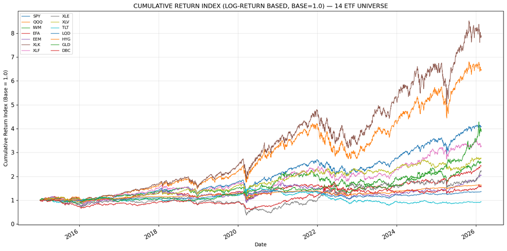

```
SAVED_FIGURE: C:\Users\steve\Documents\01_ACADEMIA\WQU\MScFE_692_Capstone_Project\riskml-capstone\reports\figures\notebook01_cumulative_returns.png
```

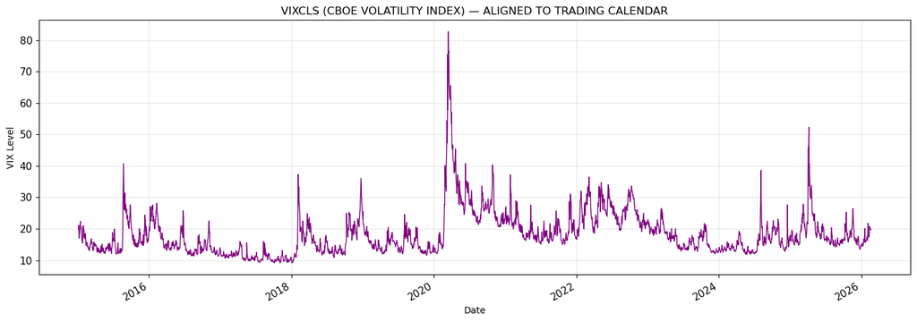

```
SAVED_FIGURE: C:\Users\steve\Documents\01_ACADEMIA\WQU\MScFE_692_Capstone_Project\riskml-capstone\reports\figures\notebook01_vix_series.png


============================================================
PLOTS_COMPLETE: 01_data_extraction.ipynb (Week 2 EDA)
============================================================
```

```python
# ============
# CODE_BLOCK_K
# ============
# =========================================================
# PLOTS: CUMULATIVE ETF RETURNS AND VIX SERIES (WEEK 2 EDA)
# =========================================================

# =====================================================
# ENSURE REPORTS FIGURES DIRECTORY EXISTS BEFORE SAVING
# =====================================================
REPORTS_FIGURES.mkdir(parents=True, exist_ok=True)

# =============================================
# FAIL FAST WHEN ETF_RETURNS DATAFRAME IS EMPTY
# =============================================
if ETF_RETURNS.shape[0] == 0:
    raise ValueError("ETF_RETURNS_EMPTY_CANNOT_PLOT")

# ================================================
# COMPUTE CUMULATIVE RETURN INDEX FROM LOG RETURNS
# ================================================
cum_return_index = np.exp(ETF_RETURNS.cumsum())

# ==========================================================
# NORMALIZE CUMULATIVE INDEX TO START AT 1.0 FOR READABILITY
# ==========================================================
cum_return_index = cum_return_index / cum_return_index.iloc[0]

# =======================================================
# CREATE FIGURE FOR CUMULATIVE RETURNS WITH ADEQUATE SIZE
# =======================================================
fig1, ax1 = plt.subplots(figsize=(14, 7))

# ============================================
# PLOT CUMULATIVE RETURN INDEX FOR ALL 14 ETFS
# ============================================
cum_return_index.plot(ax=ax1, linewidth=1.0)

# =====================================================
# SET TITLE AND AXIS LABELS FOR CUMULATIVE RETURNS PLOT
# =====================================================
ax1.set_title("CUMULATIVE RETURN INDEX (LOG-RETURN BASED, BASE=1.0) — 14 ETF UNIVERSE", fontsize=12)
ax1.set_xlabel("Date", fontsize=10)
ax1.set_ylabel("Cumulative Return Index (Base = 1.0)", fontsize=10)

# ========================================================
# POSITION LEGEND OUTSIDE PLOT AREA FOR 14 ETF READABILITY
# ========================================================
ax1.legend(loc="upper left", fontsize=8, ncol=2)

# ===============================
# ADD GRID FOR VISUAL READABILITY
# ===============================
ax1.grid(True, alpha=0.3)

# ============================
# TIGHTEN LAYOUT BEFORE SAVING
# ============================
fig1.tight_layout()

# ===============================================
# DEFINE OUTPUT PATH FOR CUMULATIVE RETURN FIGURE
# ===============================================
path_cum_fig = REPORTS_FIGURES / "notebook01_cumulative_returns.png"

# ========================================
# SAVE FIGURE TO REPORTS FIGURES DIRECTORY
# ========================================
fig1.savefig(path_cum_fig, dpi=150, bbox_inches="tight")

# ==============================
# SHOW FIGURE IN NOTEBOOK OUTPUT
# ==============================
plt.show()

# ===========================
# CLOSE FIGURE TO FREE MEMORY
# ===========================
plt.close(fig1)

# ==================================
# PRINT FIGURE PATH FOR TRACEABILITY
# ==================================
print(f"SAVED_FIGURE: {path_cum_fig}")
print("\n")

# =============================================
# VALIDATE VIXCLS COLUMN EXISTS BEFORE PLOTTING
# =============================================
if "VIXCLS" not in MASTER_PANEL.columns:
    raise ValueError("VIXCLS_COLUMN_NOT_FOUND_IN_MASTER_PANEL")

# ==============================================
# COERCE VIX SERIES TO NUMERIC FOR SAFE PLOTTING
# ==============================================
vix_series = pd.to_numeric(MASTER_PANEL["VIXCLS"], errors="coerce")

# =============================================
# FAIL FAST WHEN VIX SERIES IS ENTIRELY MISSING
# =============================================
if vix_series.isna().all():
    raise ValueError("VIXCLS_ALL_NAN_CANNOT_PLOT")

# ===============================================
# CREATE FIGURE FOR VIX SERIES WITH ADEQUATE SIZE
# ===============================================
fig2, ax2 = plt.subplots(figsize=(14, 5))

# =================================
# PLOT VIX SERIES FROM MASTER PANEL
# =================================
vix_series.plot(ax=ax2, color="purple", linewidth=1.0)

# ======================================
# SET TITLE AND AXIS LABELS FOR VIX PLOT
# ======================================
ax2.set_title("VIXCLS (CBOE VOLATILITY INDEX) — ALIGNED TO TRADING CALENDAR", fontsize=12)
ax2.set_xlabel("Date", fontsize=10)
ax2.set_ylabel("VIX Level", fontsize=10)

# ===============================
# ADD GRID FOR VISUAL READABILITY
# ===============================
ax2.grid(True, alpha=0.3)

# ============================
# TIGHTEN LAYOUT BEFORE SAVING
# ============================
fig2.tight_layout()

# =================================
# DEFINE OUTPUT PATH FOR VIX FIGURE
# =================================
path_vix_fig = REPORTS_FIGURES / "notebook01_vix_series.png"

# ========================================
# SAVE FIGURE TO REPORTS FIGURES DIRECTORY
# ========================================
fig2.savefig(path_vix_fig, dpi=150, bbox_inches="tight")

# ==============================
# SHOW FIGURE IN NOTEBOOK OUTPUT
# ==============================
plt.show()

# ===========================
# CLOSE FIGURE TO FREE MEMORY
# ===========================
plt.close(fig2)

# ==================================
# PRINT FIGURE PATH FOR TRACEABILITY
# ==================================
print(f"SAVED_FIGURE: {path_vix_fig}")
print("\n")

# =============================
# PRINT PLOT COMPLETION MESSAGE
# =============================
print("=" * 60)
print("PLOTS_COMPLETE: 01_data_extraction.ipynb (Week 2 EDA)")
print("=" * 60)
```

### 📌 Observations and Insights for CODE_BLOCK_K

**✅ VALIDATION STATUS:** PASSED — PLOTS COMPLETE

**⚙️ WHAT THE CODE ACCOMPLISHED:**

- Validated ETF_RETURNS DataFrame is non-empty before plotting
- Computed cumulative return index from log returns using exp(cumsum())
- Normalized cumulative index to start at 1.0 for visual comparability
- Created 14-ETF cumulative return chart with legend, grid, and axis labels
- Validated VIXCLS column exists and contains non-null values
- Created VIX time series chart aligned to trading calendar
- Saved both figures to reports/figures/ directory for MS Word insertion

**📐 CUMULATIVE RETURN INDEX INTERPRETATION**

**Formula:** $\text{CumReturn}_t = \exp\left(\sum_{i=1}^{t} r_i\right) / \exp(r_1)$

where $r_i$ is the log return on day $i$. Normalizing by the first value ensures all series start at 1.0.

[output not shown]

**COVID crash (March 2020):** Visible as sharp drawdown across all equity ETFs, with subsequent V-shaped recovery.

**🔗 VIX SERIES AND THE MANUAL DAG**

The VIX series (VIXCLS) feeds into the **Macro → Regime → Risk** pathway in the manual DAG:

```
VIXCLS  →  Regime Labels  →  Risk  →  Allocation
```

| VIX Level | Regime Interpretation | DAG Impact |
| --- | --- | --- |
| < 15 | Low volatility / Complacency | Increase risk allocation |
| 15 – 25 | Normal market conditions | Neutral allocation |
| 25 – 40 | Elevated uncertainty | Reduce risk allocation |
| > 40 | Crisis / Panic | Defensive positioning |

**📁 SAVED FIGURES FOR MS WORD REPORT**

| File | Location | Purpose |
| --- | --- | --- |
| `notebook01_cumulative_returns.png` | reports/figures/ | Chapter 4: Data Description |
| `notebook01_vix_series.png` | reports/figures/ | Chapter 4: Macro/Regime Context |

**MS Word insertion:** Insert > Pictures > select from `reports/figures/`

**✅ 01_data_extraction.ipynb COMPLETE**

All CODE_BLOCKS (A through K) executed successfully. Data freeze complete. Ready to proceed to `02_feature_engineering_ml_factors.ipynb`.

**Next step:** Begin `02_feature_engineering_ml_factors.ipynb` — compute momentum, volatility, regime labels, and populate RSS/sentiment data